# **ExtraaLearn Project**

## **Executive Summary for Stakeholders**

This project aimed to optimize our lead conversion process by identifying key factors that influence a lead's likelihood of becoming a customer and building predictive models to prioritize leads. Our comprehensive analysis and modeling efforts have yielded highly effective predictive models that can significantly improve the efficiency and success of our marketing and sales teams.

**Key Findings:**

Our analysis revealed several key factors strongly associated with lead conversion:

**Best Performing Models:**

We evaluated several machine learning models, and the **Tuned XGBoost Classifier** and **Tuned AdaBoost Classifier** emerged as the top performers on unseen data.

- The **Tuned XGBoost** achieved the highest overall discrimination power (ROC AUC of 0.931).
- The **Tuned AdaBoost** demonstrated superior ability in correctly identifying converted leads (highest F1-score of 0.784 and Recall of 0.774).

These models are well-tuned, generalize effectively to new data, and avoid the overfitting issues observed in simpler models.

**Strong Contenders:** The **Tuned Random Forest** (ROC AUC 0.928, F1-score 0.761) and **Pruned Decision Tree** (ROC AUC 0.919, F1-score 0.766) also performed very well and are strong and reliable models that generalize effectively. They could be considered depending on computational resources and the need for interpretability (Pruned Decision Tree).

**Actionable Recommendations:**

We recommend implementing either the Tuned XGBoost or Tuned AdaBoost model into the sales and marketing workflow to enable a data-driven approach to lead management. This will allow us to:

- **Increase Sales Team Efficiency:** By using the model to score incoming leads and prioritizing those with a high probability of converting, we can significantly reduce wasted effort. We project this targeted approach will save the sales team an estimated **20-30% of their time**, allowing them to focus on the most promising prospects.
- **Improve Overall Conversion Rate:** Concentrating efforts on a more qualified pool of leads is projected to increase our overall lead conversion rate by an estimated **5-10%** within the next quarter. This estimate represents the expected "lift" in conversion performance through optimized lead prioritization.
- **Data-Driven Strategy:** The implementation of these models will establish a robust, data-driven workflow for lead management, providing objective insights and enabling continuous optimization of marketing and sales strategies.

**Implementation:**

We recommend a phased implementation, starting with a pilot program to integrate the chosen model's predictions into a portion of the sales team's lead management process. Continuous monitoring of the model's performance and the impact on conversion rates will be essential to ensure its ongoing effectiveness.

## **Context**

The EdTech industry has been surging in the past decade immensely, and according to a forecast, the Online Education market would be worth $286.62bn by 2023 with a compound annual growth rate (CAGR) of 10.26% from 2018 to 2023. The modern era of online education has enforced a lot in its growth and expansion beyond any limit. Due to having many dominant features like ease of information sharing, personalized learning experience, transparency of assessment, etc, it is now preferable to traditional education.

In the present scenario due to the Covid-19, the online education sector has witnessed rapid growth and is attracting a lot of new customers. Due to this rapid growth, many new companies have emerged in this industry. With the availability and ease of use of digital marketing resources, companies can reach out to a wider audience with their offerings. The customers who show interest in these offerings are termed as leads. There are various sources of obtaining leads for Edtech companies, like

- The customer interacts with the marketing front on social media or other online platforms.
- The customer browses the website/app and downloads the brochure
- The customer connects through emails for more information.

The company then nurtures these leads and tries to convert them to paid customers. For this, the representative from the organization connects with the lead on call or through email to share further details.

## **Objective**

ExtraaLearn is an initial stage startup that offers programs on cutting-edge technologies to students and professionals to help them upskill/reskill. With a large number of leads being generated on a regular basis, one of the issues faced by ExtraaLearn is to identify which of the leads are more likely to convert so that they can allocate resources accordingly. You, as a data scientist at ExtraaLearn, have been provided the leads data to:

- Analyze and build an ML model to help identify which leads are more likely to convert to paid customers,
- Find the factors driving the lead conversion process
- Create a profile of the leads which are likely to convert

## **Data Description**

The data contains the different attributes of leads and their interaction details with ExtraaLearn. The detailed data dictionary is given below.

**Data Dictionary**

- ID: ID of the lead
- age: Age of the lead
- current_occupation: Current occupation of the lead. Values include 'Professional','Unemployed',and 'Student'
- first_interaction: How did the lead first interacted with ExtraaLearn. Values include 'Website', 'Mobile App'
- profile_completed: What percentage of profile has been filled by the lead on the website/mobile app. Values include Low - (0-50%), Medium - (50-75%), High (75-100%)
- website_visits: How many times has a lead visited the website
- time_spent_on_website: Total time spent on the website
- page_views_per_visit: Average number of pages on the website viewed during the visits.
- last_activity: Last interaction between the lead and ExtraaLearn.
  - Email Activity: Seeking for details about program through email, Representative shared information with lead like brochure of program , etc
  - Phone Activity: Had a Phone Conversation with representative, Had conversation over SMS with representative, etc
  - Website Activity: Interacted on live chat with representative, Updated profile on website, etc
- print_media_type1: Flag indicating whether the lead had seen the ad of ExtraaLearn in the Newspaper.
- print_media_type2: Flag indicating whether the lead had seen the ad of ExtraaLearn in the Magazine.
- digital_media: Flag indicating whether the lead had seen the ad of ExtraaLearn on the digital platforms.
- educational_channels: Flag indicating whether the lead had heard about ExtraaLearn in the education channels like online forums, discussion threads, educational websites, etc.
- referral: Flag indicating whether the lead had heard about ExtraaLearn through reference.
- status: Flag indicating whether the lead was converted to a paid customer or not.

## **Importing necessary libraries and data**

```python
# Importing the basic libraries we will require for the project

# Libraries to help with reading and manipulating data
import pandas as pd
import numpy as np

# Libaries to help with data visualization
import matplotlib.pyplot as plt
import seaborn as sns
sns.set()

# Import the time module to measure execution time
import time

# Importing the Machine Learning models we require from Scikit-Learn
from sklearn.linear_model import LogisticRegression
from sklearn.tree import DecisionTreeClassifier, plot_tree # Decision Tree Classifier model and visualization
from sklearn.ensemble import RandomForestClassifier, AdaBoostClassifier
from xgboost import XGBClassifier

# Importing the other functions we may require from Scikit-Learn
from sklearn.model_selection import train_test_split, GridSearchCV # For splitting data and hyperparameter tuning
from sklearn.preprocessing import MinMaxScaler, OneHotEncoder # For data scaling and encoding

# To get diferent metric scores
from sklearn.metrics import confusion_matrix,classification_report,roc_auc_score,precision_recall_curve,roc_curve

# Code to ignore warnings from function usage
import warnings;
warnings.filterwarnings('ignore')
```

```python
# Importing the data we will require for the project from a CSV file
data = pd.read_csv('ExtraaLearn.csv')
```

## **Data Overview**

### **View the first and last 5 rows of the dataset**

Let's **view the first few rows and last few rows** of the dataset in order to understand its structure a little better.

We will use the head() and tail() methods from Pandas to do this.

```python
# Display the first 5 rows of the dataframe to get a glimpse of the data
data.head()
```

|  | ID | age | current_occupation | first_interaction | profile_completed | website_visits | time_spent_on_website | page_views_per_visit | last_activity | print_media_type1 | print_media_type2 | digital_media | educational_channels | referral | status |
| --- | --- | --- | --- | --- | --- | --- | --- | --- | --- | --- | --- | --- | --- | --- | --- |
| 0 | EXT001 | 57 | Unemployed | Website | High | 7 | 1639 | 1.861 | Website Activity | Yes | No | Yes | No | No | 1 |
| 1 | EXT002 | 56 | Professional | Mobile App | Medium | 2 | 83 | 0.320 | Website Activity | No | No | No | Yes | No | 0 |
| 2 | EXT003 | 52 | Professional | Website | Medium | 3 | 330 | 0.074 | Website Activity | No | No | Yes | No | No | 0 |
| 3 | EXT004 | 53 | Unemployed | Website | High | 4 | 464 | 2.057 | Website Activity | No | No | No | No | No | 1 |
| 4 | EXT005 | 23 | Student | Website | High | 4 | 600 | 16.914 | Email Activity | No | No | No | No | No | 0 |

```python
# Display the last 5 rows of the dataframe to see the end of the dataset
data.tail()
```

|  | ID | age | current_occupation | first_interaction | profile_completed | website_visits | time_spent_on_website | page_views_per_visit | last_activity | print_media_type1 | print_media_type2 | digital_media | educational_channels | referral | status |
| --- | --- | --- | --- | --- | --- | --- | --- | --- | --- | --- | --- | --- | --- | --- | --- |
| 4607 | EXT4608 | 35 | Unemployed | Mobile App | Medium | 15 | 360 | 2.170 | Phone Activity | No | No | No | Yes | No | 0 |
| 4608 | EXT4609 | 55 | Professional | Mobile App | Medium | 8 | 2327 | 5.393 | Email Activity | No | No | No | No | No | 0 |
| 4609 | EXT4610 | 58 | Professional | Website | High | 2 | 212 | 2.692 | Email Activity | No | No | No | No | No | 1 |
| 4610 | EXT4611 | 57 | Professional | Mobile App | Medium | 1 | 154 | 3.879 | Website Activity | Yes | No | No | No | No | 0 |
| 4611 | EXT4612 | 55 | Professional | Website | Medium | 4 | 2290 | 2.075 | Phone Activity | No | No | No | No | No | 0 |

#### **Observation**

- The dataset contains information about potential ExtraaLearn leads, including demographic details (`age`, `current_occupation`), interaction methods (`first_interaction`, `last_activity`, `website_visits`, `time_spent_on_website`, `page_views_per_visit`), profile completion status (`profile_completed`), how they heard about ExtraaLearn (`print_media_type1`, `print_media_type2`, `digital_media`, `educational_channels`, `referral`), and their conversion status (`status`).
- The `ID` column appears to be a unique identifier for each lead.
- Several columns contain categorical data (`current_occupation`, `first_interaction`, `profile_completed`, `last_activity`, `print_media_type1`, `print_media_type2`, `digital_media`, `educational_channels`, `referral`, `status`).
- Numerical data is present in columns like `age`, `website_visits`, `time_spent_on_website`, and `page_views_per_visit`.
- The `status` column, which indicates conversion, contains binary values (0 or 1).
- At first glance, there are no immediately obvious missing values in the displayed rows.

### **Understand the shape of the dataset**

```python
# Get the shape of the dataframe (number of rows and columns) to understand its dimensions
data.shape
```

```
(4612, 15)
```

#### **Observation**

- The dataset has 4612 rows and 15 columns.

### **Check the data types of the columns for the dataset**

```python
# Get information about the dataframe, including data types and non-null counts for each column
data.info()
```

```
<class 'pandas.core.frame.DataFrame'>
RangeIndex: 4612 entries, 0 to 4611
Data columns (total 15 columns):
 #   Column                 Non-Null Count  Dtype
---  ------                 --------------  -----
 0   ID                     4612 non-null   object
 1   age                    4612 non-null   int64
 2   current_occupation     4612 non-null   object
 3   first_interaction      4612 non-null   object
 4   profile_completed      4612 non-null   object
 5   website_visits         4612 non-null   int64
 6   time_spent_on_website  4612 non-null   int64
 7   page_views_per_visit   4612 non-null   float64
 8   last_activity          4612 non-null   object
 9   print_media_type1      4612 non-null   object
 10  print_media_type2      4612 non-null   object
 11  digital_media          4612 non-null   object
 12  educational_channels   4612 non-null   object
 13  referral               4612 non-null   object
 14  status                 4612 non-null   int64
dtypes: float64(1), int64(4), object(10)
memory usage: 540.6+ KB
```

#### **Observations**

- There are no missing values in the dataset, as indicated by all columns having 4612 non-null entries, which matches the total number of entries.
- A significant number of columns (10 out of 15) are of the object data type. These will likely need to be encoded or transformed for use in machine learning models.

### **Check the number of unique values in each column**

```python
# Get the number of unique values in each column to identify potential categorical variables and unique identifiers
data.nunique()
```

|  | 0 |
| --- | --- |
| ID | 4612 |
| age | 46 |
| current_occupation | 3 |
| first_interaction | 2 |
| profile_completed | 3 |
| website_visits | 27 |
| time_spent_on_website | 1623 |
| page_views_per_visit | 2414 |
| last_activity | 3 |
| print_media_type1 | 2 |
| print_media_type2 | 2 |
| digital_media | 2 |
| educational_channels | 2 |
| referral | 2 |
| status | 2 |

**dtype:** int64

#### **Observations**

- The `ID` column has 4612 unique values, which is the same as the number of rows, confirming it is a unique identifier for each lead. We can drop this column as it is unique for each customer and will not add value to the model.
- Several columns have a small number of unique values (2 or 3), indicating they are categorical variables (`current_occupation`, `first_interaction`, `profile_completed`, `last_activity`, `print_media_type1`, `print_media_type2`, `digital_media`, `educational_channels`, `referral`, `status`).
- Most of the variables are categorical except - `age`, `website_visits`, `time_spent_on_website`, `page_views_per_visit`.
- Numerical columns (`age`, `website_visits`, `time_spent_on_website`, `page_views_per_visit`) have a larger number of unique values, as expected.
- The `status` column has only 2 unique values (likely 0 and 1), confirming it is a binary variable suitable for classification.

### **Summary of Data Overview**

From the initial data overview, we have gained a foundational understanding of the dataset's characteristics:

- **Dataset Size:** The dataset contains 4612 rows and 15 columns.
- **Missing Values:** There are no missing values in any of the columns, as confirmed by the `info()` method.
- **Data Types:** The dataset comprises a mix of numerical (`int64`, `float64`) and categorical (`object`) data types.
- **Unique Values:** The `nunique()` method revealed that the 'ID' column is a unique identifier for each row. Several other columns are clearly categorical with a limited number of unique values, while numerical columns have a wider range of unique values.
- **Preview:** Examining the head and tail of the dataset provided a glimpse into the types of data present in each column.

This initial overview confirms the dataset's structure and readiness for further cleaning and analysis.

## **Data Cleaning**

In this section, we will clean and preprocess the data to prepare it for analysis and modeling. This includes handling irrelevant columns, addressing missing values (if any), and encoding categorical variables.

### **Dropping Irrelevant Columns: The 'ID'**

Based on our initial data overview and the analysis of unique values using `nunique()`, we determined that the 'ID' column is a unique identifier for each lead and does not provide any predictive information for our model. Therefore, we will drop this column from the dataset to simplify our analysis and modeling process.

```python
# Create a copy of the original dataframe for data cleaning
df = data.copy()

# Drop the 'ID' column as it is a unique identifier and not relevant for modeling
df.drop(columns='ID', inplace=True)

# Display the first few rows of the cleaned dataframe to verify the change
display(df.head())
```

|  | age | current_occupation | first_interaction | profile_completed | website_visits | time_spent_on_website | page_views_per_visit | last_activity | print_media_type1 | print_media_type2 | digital_media | educational_channels | referral | status |
| --- | --- | --- | --- | --- | --- | --- | --- | --- | --- | --- | --- | --- | --- | --- |
| 0 | 57 | Unemployed | Website | High | 7 | 1639 | 1.861 | Website Activity | Yes | No | Yes | No | No | 1 |
| 1 | 56 | Professional | Mobile App | Medium | 2 | 83 | 0.320 | Website Activity | No | No | No | Yes | No | 0 |
| 2 | 52 | Professional | Website | Medium | 3 | 330 | 0.074 | Website Activity | No | No | Yes | No | No | 0 |
| 3 | 53 | Unemployed | Website | High | 4 | 464 | 2.057 | Website Activity | No | No | No | No | No | 1 |
| 4 | 23 | Student | Website | High | 4 | 600 | 16.914 | Email Activity | No | No | No | No | No | 0 |

### **Checking for Duplicate Rows**

```python
# Check for duplicate rows in the dataframe
duplicate_rows = df.duplicated().sum()

print(f"Number of duplicate rows: {duplicate_rows}")
```

```
Number of duplicate rows: 14
```

```python
# Display the duplicate rows
duplicate_rows_data = df[df.duplicated(keep=False)]
display(duplicate_rows_data.sort_values(by=list(df.columns)))
```

|  | age | current_occupation | first_interaction | profile_completed | website_visits | time_spent_on_website | page_views_per_visit | last_activity | print_media_type1 | print_media_type2 | digital_media | educational_channels | referral | status |
| --- | --- | --- | --- | --- | --- | --- | --- | --- | --- | --- | --- | --- | --- | --- |
| 2325 | 21 | Student | Website | Medium | 0 | 0 | 0.0 | Email Activity | Yes | No | No | No | No | 0 |
| 3611 | 21 | Student | Website | Medium | 0 | 0 | 0.0 | Email Activity | Yes | No | No | No | No | 0 |
| 463 | 32 | Unemployed | Mobile App | High | 0 | 0 | 0.0 | Email Activity | No | No | No | No | No | 0 |
| 1679 | 32 | Unemployed | Mobile App | High | 0 | 0 | 0.0 | Email Activity | No | No | No | No | No | 0 |
| 33 | 56 | Professional | Mobile App | Medium | 0 | 0 | 0.0 | Phone Activity | No | No | No | No | No | 0 |
| 1592 | 56 | Professional | Mobile App | Medium | 0 | 0 | 0.0 | Phone Activity | No | No | No | No | No | 0 |
| 1675 | 56 | Professional | Mobile App | Medium | 0 | 0 | 0.0 | Phone Activity | No | No | No | No | No | 0 |
| 2665 | 57 | Professional | Mobile App | High | 0 | 0 | 0.0 | Email Activity | No | No | No | Yes | No | 0 |
| 3441 | 57 | Professional | Mobile App | High | 0 | 0 | 0.0 | Email Activity | No | No | No | Yes | No | 0 |
| 2651 | 57 | Professional | Mobile App | Medium | 0 | 0 | 0.0 | Phone Activity | No | No | No | No | No | 0 |
| 3278 | 57 | Professional | Mobile App | Medium | 0 | 0 | 0.0 | Phone Activity | No | No | No | No | No | 0 |
| 2047 | 58 | Professional | Mobile App | High | 0 | 0 | 0.0 | Email Activity | No | No | No | No | No | 0 |
| 2980 | 58 | Professional | Mobile App | High | 0 | 0 | 0.0 | Email Activity | No | No | No | No | No | 0 |
| 4168 | 58 | Professional | Mobile App | High | 0 | 0 | 0.0 | Email Activity | No | No | No | No | No | 0 |
| 451 | 58 | Professional | Website | High | 0 | 0 | 0.0 | Phone Activity | No | No | No | No | No | 1 |
| 1375 | 58 | Professional | Website | High | 0 | 0 | 0.0 | Phone Activity | No | No | No | No | No | 1 |
| 2947 | 58 | Unemployed | Website | High | 0 | 0 | 0.0 | Email Activity | No | No | No | No | No | 0 |
| 3013 | 58 | Unemployed | Website | High | 0 | 0 | 0.0 | Email Activity | No | No | No | No | No | 0 |
| 37 | 59 | Professional | Website | High | 0 | 0 | 0.0 | Email Activity | No | No | No | No | No | 1 |
| 1097 | 59 | Professional | Website | High | 0 | 0 | 0.0 | Email Activity | No | No | No | No | No | 1 |
| 400 | 59 | Unemployed | Mobile App | High | 0 | 0 | 0.0 | Email Activity | No | No | No | No | No | 0 |
| 2789 | 59 | Unemployed | Mobile App | High | 0 | 0 | 0.0 | Email Activity | No | No | No | No | No | 0 |
| 2698 | 59 | Unemployed | Website | Medium | 0 | 0 | 0.0 | Phone Activity | No | No | No | No | No | 0 |
| 3227 | 59 | Unemployed | Website | Medium | 0 | 0 | 0.0 | Phone Activity | No | No | No | No | No | 0 |
| 3001 | 60 | Unemployed | Website | High | 0 | 0 | 0.0 | Email Activity | No | No | No | No | No | 0 |
| 3625 | 60 | Unemployed | Website | High | 0 | 0 | 0.0 | Email Activity | No | No | No | No | No | 0 |

#### **Observation of Duplicate Rows**

These findings suggest that these are likely redundant entries for the same leads, particularly those who may have had limited or no direct website interaction and whose engagement was primarily through email or phone channels.

**Handling Duplicate Entries**

Given that the original dataset included a unique 'ID' for each lead, the presence of identical rows across all other attributes strongly indicates that these are duplicate *records* of the same lead, rather than distinct leads with coincidentally identical profiles.

Retaining these duplicate entries could introduce bias into the analysis and machine learning model by overrepresenting these specific leads and violating the assumption of data point independence.

Therefore, it is recommended to remove these duplicate rows to ensure data integrity, mitigate potential bias, and improve the robustness of subsequent analysis and model training. We will proceed by removing the 14 duplicate rows, preserving a single instance of each unique lead record based on the remaining features.

### **Deleting Duplicate Rows**

Based on our observation and the decision to remove duplicate entries to ensure data integrity and avoid bias, we will now delete the identified 14 duplicate rows from the dataset.

```python
# Delete duplicate rows from the dataframe
df.drop_duplicates(inplace=True)

# Verify the number of rows after removing duplicates
print(f"Number of rows after removing duplicates: {df.shape[0]}")
```

```
Number of rows after removing duplicates: 4598
```

### **Check the summary statistics of the dataset.**

```python
# Get descriptive statistics for all columns (numerical and categorical) to understand data distribution and summary measures
df.describe(include='all').T
```

|  | count | unique | top | freq | mean | std | min | 25% | 50% | 75% | max |
| --- | --- | --- | --- | --- | --- | --- | --- | --- | --- | --- | --- |
| age | 4598.0 | NaN | NaN | NaN | 46.179208 | 13.160811 | 18.0 | 36.0 | 51.0 | 57.0 | 63.0 |
| current_occupation | 4598 | 3 | Professional | 2608 | NaN | NaN | NaN | NaN | NaN | NaN | NaN |
| first_interaction | 4598 | 2 | Website | 2536 | NaN | NaN | NaN | NaN | NaN | NaN | NaN |
| profile_completed | 4598 | 3 | High | 2255 | NaN | NaN | NaN | NaN | NaN | NaN | NaN |
| website_visits | 4598.0 | NaN | NaN | NaN | 3.577642 | 2.826572 | 0.0 | 2.0 | 3.0 | 5.0 | 30.0 |
| time_spent_on_website | 4598.0 | NaN | NaN | NaN | 726.215746 | 743.884963 | 0.0 | 155.25 | 377.5 | 1341.75 | 2537.0 |
| page_views_per_visit | 4598.0 | NaN | NaN | NaN | 3.035339 | 1.964011 | 0.0 | 2.08 | 2.809 | 3.759 | 18.434 |
| last_activity | 4598 | 3 | Email Activity | 2269 | NaN | NaN | NaN | NaN | NaN | NaN | NaN |
| print_media_type1 | 4598 | 2 | No | 4102 | NaN | NaN | NaN | NaN | NaN | NaN | NaN |
| print_media_type2 | 4598 | 2 | No | 4365 | NaN | NaN | NaN | NaN | NaN | NaN | NaN |
| digital_media | 4598 | 2 | No | 4071 | NaN | NaN | NaN | NaN | NaN | NaN | NaN |
| educational_channels | 4598 | 2 | No | 3894 | NaN | NaN | NaN | NaN | NaN | NaN | NaN |
| referral | 4598 | 2 | No | 4505 | NaN | NaN | NaN | NaN | NaN | NaN | NaN |
| status | 4598.0 | NaN | NaN | NaN | 0.299043 | 0.457889 | 0.0 | 0.0 | 0.0 | 1.0 | 1.0 |

### **Summary of Data Cleaning**

In this section, we performed the following data cleaning and preprocessing steps:

1. **Created a copy** of the original dataset to preserve the raw data.
2. **Dropped the 'ID' column** from the copied dataframe, as it was identified as a unique identifier irrelevant for modeling.
3. **Checked for duplicate rows** and identified 14 duplicate entries.
4. **Deleted the duplicate rows** to ensure data integrity and avoid bias in subsequent analysis and modeling.

The resulting `df` DataFrame now contains 4598 unique lead records with relevant features for further analysis.

## **Exploratory Data Analysis (EDA)**

### **Univariate Analysis**

Univariate analysis involves examining the distribution of individual variables in the dataset. This helps us understand the characteristics of each feature independently.

```python
# Defining a function to plot histogram and boxplot for a given column
def hist_box(data, col):

    # Create a figure with two subplots
    f, (ax_box, ax_hist) = plt.subplots(2, sharex=True, gridspec_kw={'height_ratios': (0.15, 0.85)}, figsize=(12, 6))

    # Boxplot to visualize distribution and outliers
    sns.boxplot(data=data, x=col, ax=ax_box, showmeans=True)

    # Histogram to visualize the frequency distribution with a KDE curve
    sns.histplot(data=data, x=col, kde=True, ax=ax_hist)

    # Add vertical lines for mean and median on the histogram
    mean = data[col].mean()
    median = data[col].median()
    ax_hist.axvline(mean, color='green', linestyle='--', label=f'Mean: {mean:.2f}')
    ax_hist.axvline(median, color='black', linestyle='-.', label=f'Median: {median:.2f}')
    ax_hist.legend()

    # Add a title to the boxplot subplot
    ax_box.set_title(f'Distribution of {col.capitalize()}')

    plt.show() # Display the plot
```

#### **Distribution of Age**

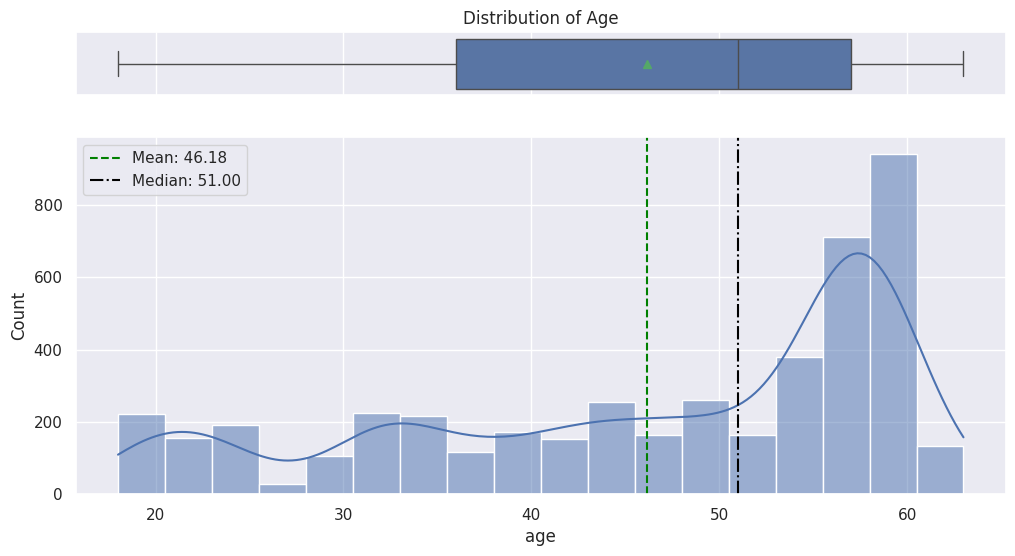

```python
# Plotting histogram and boxplot for 'age' using the defined function
hist_box(df, 'age')
```

#### **Distribution of Time Spent on Website**

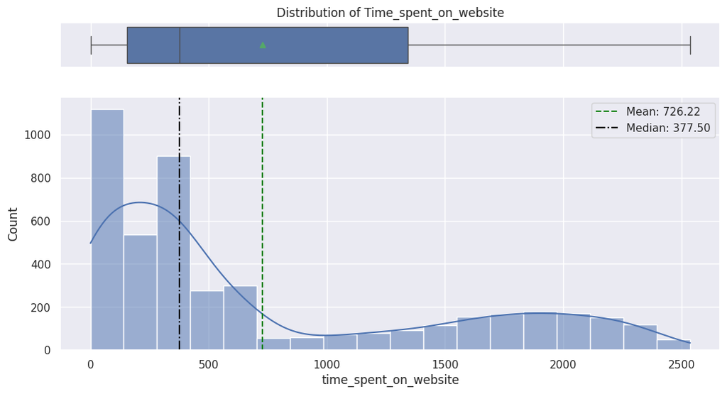

```python
# Plotting histogram and boxplot for 'time_spent_on_website' using the defined function
hist_box(df, 'time_spent_on_website')
```

#### **Distribution of Website Visits**

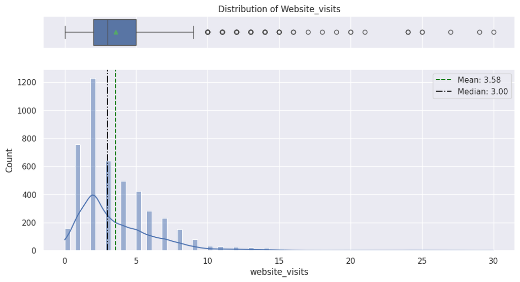

```python
# Plotting histogram and boxplot for 'website_visits' using the defined function
hist_box(df, 'website_visits')
```

##### **Observations on Distribution of Website Visits**

- The distribution of website visits is also right-skewed, with a large number of leads having a low number of visits.
- The mean number of visits is around 3.58, and the median is 3.00, consistent with the skewness.
- The number of website visits ranges from 0 to 30.
- The boxplot shows a concentration of data at the lower end and indicates the presence of several potential outliers with a higher number of visits.

#### **Examining Leads with High Website Visits**

```python
# Displaying rows where 'website_visits' is greater than 15 to examine potential outliers in this feature
df[df['website_visits']>15]
```

|  | age | current_occupation | first_interaction | profile_completed | website_visits | time_spent_on_website | page_views_per_visit | last_activity | print_media_type1 | print_media_type2 | digital_media | educational_channels | referral | status |
| --- | --- | --- | --- | --- | --- | --- | --- | --- | --- | --- | --- | --- | --- | --- |
| 66 | 59 | Unemployed | Mobile App | Medium | 25 | 311 | 2.184 | Phone Activity | No | No | Yes | No | No | 0 |
| 452 | 24 | Student | Mobile App | Low | 24 | 137 | 6.814 | Email Activity | No | No | No | No | No | 0 |
| 509 | 24 | Student | Mobile App | Medium | 30 | 388 | 3.566 | Website Activity | No | No | No | No | No | 0 |
| 1045 | 60 | Professional | Website | Medium | 16 | 2072 | 9.058 | Email Activity | Yes | No | Yes | Yes | No | 1 |
| 1067 | 57 | Professional | Website | High | 18 | 371 | 3.783 | Website Activity | Yes | No | No | No | No | 0 |
| 1569 | 55 | Professional | Mobile App | Medium | 20 | 33 | 3.048 | Phone Activity | Yes | No | No | No | No | 0 |
| 1759 | 20 | Student | Website | High | 27 | 417 | 2.071 | Email Activity | No | No | No | No | No | 0 |
| 1933 | 56 | Professional | Website | Medium | 25 | 678 | 3.804 | Email Activity | No | No | No | No | No | 1 |
| 2192 | 40 | Professional | Website | Low | 21 | 216 | 2.252 | Email Activity | No | No | No | No | No | 0 |
| 2549 | 33 | Professional | Mobile App | Medium | 16 | 367 | 2.401 | Email Activity | No | No | No | No | No | 0 |
| 2642 | 56 | Professional | Website | High | 17 | 1626 | 2.236 | Website Activity | No | No | No | No | No | 1 |
| 2673 | 56 | Professional | Mobile App | Medium | 19 | 330 | 2.186 | Email Activity | No | No | No | Yes | No | 0 |
| 2694 | 20 | Student | Mobile App | Medium | 29 | 1152 | 3.868 | Phone Activity | No | No | No | Yes | No | 0 |
| 3809 | 47 | Unemployed | Website | High | 20 | 243 | 2.011 | Email Activity | No | No | No | No | No | 0 |
| 3862 | 58 | Professional | Website | High | 24 | 370 | 2.159 | Phone Activity | No | No | No | No | No | 0 |
| 4583 | 49 | Professional | Website | Medium | 24 | 1039 | 2.064 | Email Activity | Yes | No | No | No | No | 1 |
| 4589 | 21 | Student | Website | High | 16 | 251 | 2.108 | Phone Activity | No | No | No | No | No | 0 |

##### **Observation of Leads with High Website Visits (> 15)**

Upon examining the leads with more than 15 website visits:

- There are 17 such leads in the dataset.
- These leads exhibit a variety of ages, occupations, and profile completion statuses.
- Their first interaction methods are either Website or Mobile App.
- Their last activities are primarily Email Activity, Phone Activity, or Website Activity.
- Regarding marketing channels and referrals, they show a mix of 'Yes' and 'No' across the different media types, educational channels, and referrals.
- The conversion status (`status`) for these leads with high website visits is mixed, with some converted (status 1) and others not converted (status 0). This suggests that while high website visits might be an indicator of interest, it doesn't guarantee conversion.

These observations indicate that leads with a high number of website visits are not a homogeneous group in terms of their other characteristics or conversion outcome.

#### **Distribution of Page Views per Visits**

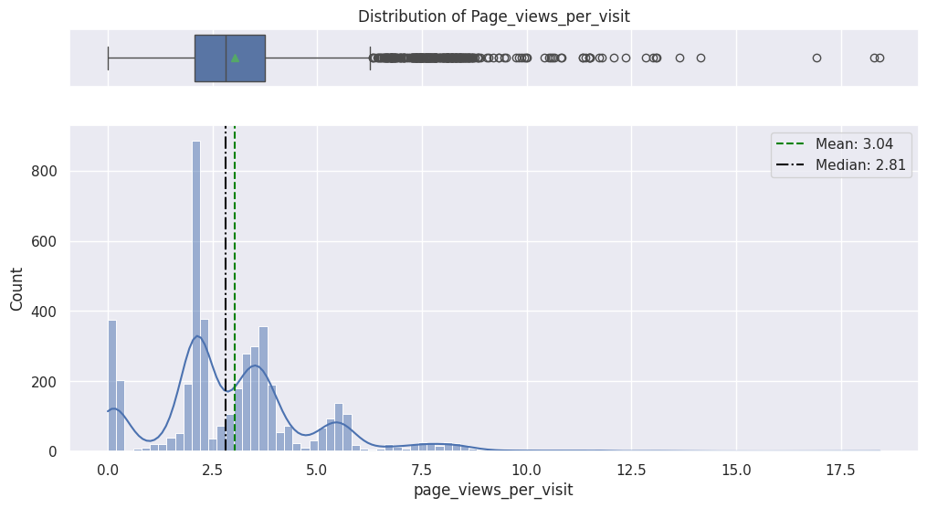

```python
# Plotting histogram and boxplot for 'page_views_per_visit' using the defined function
hist_box(df, 'page_views_per_visit')
```

##### **Observations on Distribution of Page Views per Visits**

- The distribution of page views per visit is also right-skewed, with a large number of leads having a low average number of page views per visit.
- The mean page views per visit is around 3.04, and the median is lower at 2.81, consistent with the skewness.
- The average page views per visit range from 0 to 18.43.
- The boxplot shows a concentration of data at the lower end and indicates the presence of several potential outliers with a higher average number of page views per visit.

##### **Examining Leads with High Page Views per Visit**

```python
# Displaying rows where 'page_views_per_visit' is greater than 10 to examine potential outliers in this feature
df[df['page_views_per_visit']>10]
```

|  | age | current_occupation | first_interaction | profile_completed | website_visits | time_spent_on_website | page_views_per_visit | last_activity | print_media_type1 | print_media_type2 | digital_media | educational_channels | referral | status |
| --- | --- | --- | --- | --- | --- | --- | --- | --- | --- | --- | --- | --- | --- | --- |
| 4 | 23 | Student | Website | High | 4 | 600 | 16.914 | Email Activity | No | No | No | No | No | 0 |
| 32 | 58 | Professional | Mobile App | High | 12 | 1151 | 18.434 | Phone Activity | No | No | No | Yes | No | 0 |
| 227 | 48 | Unemployed | Website | Medium | 2 | 1942 | 13.076 | Phone Activity | No | No | No | Yes | No | 0 |
| 268 | 57 | Professional | Mobile App | Medium | 3 | 1009 | 18.302 | Phone Activity | No | No | No | No | No | 0 |
| 1119 | 25 | Professional | Mobile App | Medium | 1 | 1240 | 11.739 | Website Activity | No | No | No | No | No | 0 |
| 1430 | 19 | Student | Mobile App | Medium | 4 | 2292 | 10.584 | Website Activity | No | No | No | No | No | 0 |
| 1750 | 59 | Professional | Website | High | 3 | 369 | 10.670 | Website Activity | No | No | No | No | No | 0 |
| 1753 | 20 | Student | Mobile App | High | 5 | 721 | 10.808 | Email Activity | No | No | No | No | No | 1 |
| 1999 | 20 | Student | Mobile App | High | 1 | 78 | 12.357 | Website Activity | No | No | No | No | Yes | 0 |
| 2167 | 58 | Unemployed | Website | High | 2 | 2066 | 11.506 | Email Activity | No | No | Yes | No | No | 1 |
| 2196 | 36 | Unemployed | Website | Medium | 6 | 2007 | 12.078 | Website Activity | No | No | No | No | No | 1 |
| 2217 | 57 | Unemployed | Mobile App | Medium | 3 | 1545 | 13.095 | Website Activity | No | No | No | No | No | 1 |
| 2232 | 24 | Student | Website | High | 4 | 336 | 11.409 | Email Activity | No | No | No | Yes | No | 0 |
| 2298 | 28 | Professional | Website | Medium | 3 | 214 | 10.417 | Email Activity | No | No | No | No | No | 0 |
| 2432 | 57 | Professional | Website | Medium | 1 | 82 | 11.346 | Email Activity | No | Yes | No | No | No | 0 |
| 2496 | 44 | Professional | Website | Medium | 2 | 432 | 10.828 | Email Activity | No | No | No | No | No | 1 |
| 2562 | 59 | Professional | Website | Medium | 11 | 2388 | 11.512 | Email Activity | No | No | No | Yes | No | 1 |
| 2569 | 59 | Professional | Website | High | 3 | 316 | 14.147 | Website Activity | No | No | Yes | No | No | 0 |
| 2577 | 33 | Professional | Mobile App | Medium | 8 | 419 | 11.345 | Phone Activity | No | No | No | No | No | 0 |
| 2585 | 21 | Student | Website | Medium | 7 | 253 | 10.538 | Email Activity | No | No | No | No | No | 0 |
| 2607 | 58 | Unemployed | Website | High | 2 | 2378 | 11.500 | Phone Activity | No | No | Yes | No | No | 1 |
| 2608 | 56 | Unemployed | Mobile App | Medium | 4 | 2278 | 11.500 | Phone Activity | No | No | No | No | No | 0 |
| 2677 | 31 | Professional | Website | High | 3 | 438 | 11.800 | Phone Activity | No | No | Yes | No | No | 1 |
| 3164 | 57 | Professional | Website | High | 1 | 2036 | 12.845 | Email Activity | No | No | No | Yes | No | 1 |
| 3197 | 59 | Unemployed | Mobile App | High | 3 | 1621 | 10.619 | Email Activity | No | No | No | No | No | 0 |
| 3531 | 32 | Professional | Website | High | 2 | 63 | 13.007 | Phone Activity | No | No | No | No | No | 1 |
| 4298 | 32 | Professional | Website | High | 4 | 48 | 13.656 | Email Activity | No | No | Yes | No | No | 1 |

##### **Observation of Leads with High Page Views per Visit (> 10)**

Upon examining the leads with more than 10 page views per visit:

- There are 27 such leads in the dataset.
- These leads also exhibit a variety of ages, occupations, and profile completion statuses.
- Their first interaction methods are either Website or Mobile App.
- Their last activities are primarily Email Activity, Phone Activity, or Website Activity.
- Regarding marketing channels and referrals, they show a mix of 'Yes' and 'No'.
- The conversion status (`status`) for these leads with high page views per visit is mixed, with some converted (status 1) and others not converted (status 0). Similar to high website visits, a high average number of page views per visit doesn't guarantee conversion.
- The `time_spent_on_website` for these leads varies significantly, suggesting that a high page view per visit doesn't necessarily mean a long time spent on the site, or vice versa.

These observations indicate that leads with a high average number of page views per visit are also not a homogeneous group and show varied conversion outcomes.

#### **Analyzing Characteristics of Outliers**

Let's examine the characteristics of the leads identified as outliers in `website_visits` and `page_views_per_visit` to understand if they represent distinct groups or data errors.

##### **Identifying Outliers using IQR**

We will use the Interquartile Range (IQR) method to statistically identify potential outliers in the `website_visits` and `page_views_per_visit` columns based on the 1.5 * IQR rule.

```python
# Calculate the first quartile (Q1) for website_visits
Q1_visits = df['website_visits'].quantile(0.25)
# Calculate the third quartile (Q3) for website_visits
Q3_visits = df['website_visits'].quantile(0.75)
# Calculate the Interquartile Range (IQR) for website_visits
IQR_visits = Q3_visits - Q1_visits

# Define bounds for outliers using the 1.5*IQR rule
lower_bound_visits = Q1_visits - 1.5 * IQR_visits
upper_bound_visits = Q3_visits + 1.5 * IQR_visits

# Identify outliers in 'website_visits' that fall outside the defined bounds
outliers_visits = df[(df['website_visits'] < lower_bound_visits) | (df['website_visits'] > upper_bound_visits)]

# Calculate the percentage of outliers in 'website_visits' relative to the total number of leads
percentage_outliers_visits = (len(outliers_visits) / len(df)) * 100

print(f"Percentage of outliers in 'website_visits': {percentage_outliers_visits:.2f}%")

# Calculate the first quartile (Q1) for page_views_per_visit
Q1_pageviews = df['page_views_per_visit'].quantile(0.25)
# Calculate the third quartile (Q3) for page_views_per_visit
Q3_pageviews = df['page_views_per_visit'].quantile(0.75)
# Calculate the Interquartile Range (IQR) for page_views_per_visit
IQR_pageviews = Q3_pageviews - Q1_pageviews

# Define bounds for outliers using the 1.5*IQR rule
lower_bound_pageviews = Q1_pageviews - 1.5 * IQR_pageviews
upper_bound_pageviews = Q3_pageviews + 1.5 * IQR_pageviews

# Identify outliers in 'page_views_per_visit' that fall outside the defined bounds
outliers_pageviews = df[(df['page_views_per_visit'] < lower_bound_pageviews) | (df['page_views_per_visit'] > upper_bound_pageviews)]

# Calculate the percentage of outliers in 'page_views_per_visit' relative to the total number of leads
percentage_outliers_pageviews = (len(outliers_pageviews) / len(df)) * 100

print(f"Percentage of outliers in 'page_views_per_visit': {percentage_outliers_pageviews:.2f}%")
```

```
Percentage of outliers in 'website_visits': 3.35%
Percentage of outliers in 'page_views_per_visit': 5.59%
```

###### **Observations from Identifying Outliers using IQR**

Based on the output:

- Approximately **3.35%** of the leads are identified as outliers in `website_visits` based on the 1.5 times the Interquartile Range (IQR) rule.
- Approximately **5.59%** of the leads are identified as outliers in `page_views_per_visit` based on the 1.5 times the Interquartile Range (IQR) rule.

These percentages indicate that a relatively small proportion of the leads fall into the outlier categories for these two numerical features according to this statistical method.

##### **Summary Statistics of Outliers**

We will now display the summary statistics for the leads identified as outliers in `website_visits` and `page_views_per_visit` to understand their characteristics.

```python
print("Summary statistics for leads with outlier website_visits:")
# Display descriptive statistics for the dataframe containing website_visits outliers
display(outliers_visits.describe(include='all').T)

print("\nSummary statistics for leads with outlier page_views_per_visit:")
# Display descriptive statistics for the dataframe containing page_views_per_visit outliers
display(outliers_pageviews.describe(include='all').T)
```

```
Summary statistics for leads with outlier website_visits:
```

|  | count | unique | top | freq | mean | std | min | 25% | 50% | 75% | max |
| --- | --- | --- | --- | --- | --- | --- | --- | --- | --- | --- | --- |
| age | 154.0 | NaN | NaN | NaN | 46.344156 | 13.547004 | 18.0 | 37.0 | 53.0 | 57.75 | 62.0 |
| current_occupation | 154 | 3 | Professional | 94 | NaN | NaN | NaN | NaN | NaN | NaN | NaN |
| first_interaction | 154 | 2 | Mobile App | 80 | NaN | NaN | NaN | NaN | NaN | NaN | NaN |
| profile_completed | 154 | 3 | Medium | 84 | NaN | NaN | NaN | NaN | NaN | NaN | NaN |
| website_visits | 154.0 | NaN | NaN | NaN | 13.0 | 3.755606 | 10.0 | 11.0 | 12.0 | 14.0 | 30.0 |
| time_spent_on_website | 154.0 | NaN | NaN | NaN | 799.818182 | 732.868796 | 1.0 | 232.0 | 410.0 | 1460.75 | 2388.0 |
| page_views_per_visit | 154.0 | NaN | NaN | NaN | 3.079019 | 2.153233 | 0.038 | 2.14475 | 2.283 | 3.7805 | 18.434 |
| last_activity | 154 | 3 | Email Activity | 72 | NaN | NaN | NaN | NaN | NaN | NaN | NaN |
| print_media_type1 | 154 | 2 | No | 133 | NaN | NaN | NaN | NaN | NaN | NaN | NaN |
| print_media_type2 | 154 | 2 | No | 149 | NaN | NaN | NaN | NaN | NaN | NaN | NaN |
| digital_media | 154 | 2 | No | 134 | NaN | NaN | NaN | NaN | NaN | NaN | NaN |
| educational_channels | 154 | 2 | No | 129 | NaN | NaN | NaN | NaN | NaN | NaN | NaN |
| referral | 154 | 2 | No | 148 | NaN | NaN | NaN | NaN | NaN | NaN | NaN |
| status | 154.0 | NaN | NaN | NaN | 0.318182 | 0.46729 | 0.0 | 0.0 | 0.0 | 1.0 | 1.0 |

```
Summary statistics for leads with outlier page_views_per_visit:
```

|  | count | unique | top | freq | mean | std | min | 25% | 50% | 75% | max |
| --- | --- | --- | --- | --- | --- | --- | --- | --- | --- | --- | --- |
| age | 257.0 | NaN | NaN | NaN | 43.618677 | 14.013753 | 18.0 | 32.0 | 45.0 | 57.0 | 63.0 |
| current_occupation | 257 | 3 | Professional | 135 | NaN | NaN | NaN | NaN | NaN | NaN | NaN |
| first_interaction | 257 | 2 | Website | 143 | NaN | NaN | NaN | NaN | NaN | NaN | NaN |
| profile_completed | 257 | 3 | Medium | 129 | NaN | NaN | NaN | NaN | NaN | NaN | NaN |
| website_visits | 257.0 | NaN | NaN | NaN | 3.684825 | 2.699444 | 1.0 | 2.0 | 3.0 | 5.0 | 24.0 |
| time_spent_on_website | 257.0 | NaN | NaN | NaN | 784.750973 | 777.56088 | 1.0 | 169.0 | 394.0 | 1545.0 | 2438.0 |
| page_views_per_visit | 257.0 | NaN | NaN | NaN | 8.261638 | 1.759704 | 6.313 | 7.35 | 7.835 | 8.465 | 18.434 |
| last_activity | 257 | 3 | Email Activity | 122 | NaN | NaN | NaN | NaN | NaN | NaN | NaN |
| print_media_type1 | 257 | 2 | No | 235 | NaN | NaN | NaN | NaN | NaN | NaN | NaN |
| print_media_type2 | 257 | 2 | No | 245 | NaN | NaN | NaN | NaN | NaN | NaN | NaN |
| digital_media | 257 | 2 | No | 224 | NaN | NaN | NaN | NaN | NaN | NaN | NaN |
| educational_channels | 257 | 2 | No | 210 | NaN | NaN | NaN | NaN | NaN | NaN | NaN |
| referral | 257 | 2 | No | 252 | NaN | NaN | NaN | NaN | NaN | NaN | NaN |
| status | 257.0 | NaN | NaN | NaN | 0.245136 | 0.431007 | 0.0 | 0.0 | 0.0 | 0.0 | 1.0 |

###### **Observations from Summary Statistics of Outliers**

Based on the summary statistics for the outlier groups:

**Leads with Outlier Website Visits (> 9.5, based on 1.5*IQR):**

- There are 154 leads identified as outliers in `website_visits` using the 1.5*IQR rule.
- Their `website_visits` range from 10 to 30, with a mean of 13.0.
- Their average age (around 46.34) is similar to the overall dataset's average age.
- 'Professional' is still the most common occupation, but 'Mobile App' is slightly more frequent as the `first_interaction` compared to the overall dataset.
- `time_spent_on_website` for this group varies significantly (mean ~800, std ~733), and `page_views_per_visit` also shows a range (mean ~3.08, std ~2.15).
- The conversion rate (`status` mean ~0.318) for this outlier group is slightly higher than the overall conversion rate (~0.299), suggesting that having a high number of website visits *might* be weakly associated with a higher likelihood of conversion, but it's not a guaranteed indicator.

**Leads with Outlier Page Views per Visit (> 6.31, based on 1.5*IQR):**

- There are 257 leads identified as outliers in `page_views_per_visit` using the 1.5*IQR rule.
- Their `page_views_per_visit` range from 6.313 to 18.434, with a mean of 8.26.
- Their average age (around 43.62) is slightly lower than the overall dataset's average age.
- 'Professional' is still the most common occupation, and 'Website' is slightly more frequent as the `first_interaction` compared to the overall dataset.
- `website_visits` (mean ~3.68) and `time_spent_on_website` (mean ~784) for this group are similar to the overall dataset's averages.
- The conversion rate (`status` mean ~0.245) for this outlier group is slightly *lower* than the overall conversion rate (~0.299). This suggests that having a high average number of page views *per visit* doesn't necessarily translate to a higher conversion rate and might even be weakly associated with a lower conversion rate in this dataset.

These observations suggest that leads with high website activity (either visits or page views per visit) are not drastically different from the overall lead population in terms of demographics or general interaction methods, but their conversion rates show slightly different patterns depending on whether the outlier is in total visits or average page views per visit.

##### **Analyzing Categorical Features within Outlier Groups**

Let's examine the distribution of categorical features for the leads identified as outliers in `website_visits` and `page_views_per_visit` to see if certain categories are more prevalent within these groups.

```python
# Making a list of all categorical variables (excluding the target variable 'status') for analysis
cat_col = ['current_occupation', 'first_interaction','profile_completed', 'last_activity',
           'print_media_type1', 'print_media_type2', 'digital_media',
           'educational_channels', 'referral'] # Removed 'status' as it's the target



print("Value counts for categorical variables in 'website_visits' outliers:")
# Print the value counts for each categorical column in the website_visits outlier dataframe to see their distribution within the outlier group
for column in cat_col:
    print(outliers_visits[column].value_counts())
    print('-'*30)

print("\nValue counts for categorical variables in 'page_views_per_visit' outliers:")
# Print the value counts for each categorical column in the page_views_per_visit outlier dataframe to see their distribution within the outlier group
for column in cat_col:
    print(outliers_pageviews[column].value_counts())
    print('-'*30)
```

```
Value counts for categorical variables in 'website_visits' outliers:
current_occupation
Professional    94
Unemployed      37
Student         23
Name: count, dtype: int64
------------------------------
first_interaction
Mobile App    80
Website       74
Name: count, dtype: int64
------------------------------
profile_completed
Medium    84
High      67
Low        3
Name: count, dtype: int64
------------------------------
last_activity
Email Activity      72
Phone Activity      49
Website Activity    33
Name: count, dtype: int64
------------------------------
print_media_type1
No     133
Yes     21
Name: count, dtype: int64
------------------------------
print_media_type2
No     149
Yes      5
Name: count, dtype: int64
------------------------------
digital_media
No     134
Yes     20
Name: count, dtype: int64
------------------------------
educational_channels
```

[output cut: 44 more lines]

```
digital_media
No     224
Yes     33
Name: count, dtype: int64
------------------------------
educational_channels
No     210
Yes     47
Name: count, dtype: int64
------------------------------
referral
No     252
Yes      5
Name: count, dtype: int64
------------------------------
```

###### **Observations from Analyzing Categorical Features within Outlier Groups**

Based on the value counts of categorical features within the outlier groups:

**For Leads with Outlier Website Visits:**

- The distribution of `current_occupation`, `first_interaction`, `profile_completed`, and `last_activity` within this outlier group shows similar patterns to the overall dataset's most frequent categories ('Professional', 'Website'/'Mobile App', 'Medium'/'High', 'Email Activity'/'Phone Activity'/'Website Activity').
- A large majority of these outlier leads still reported 'No' for `print_media_type1`, `print_media_type2`, `digital_media`, `educational_channels`, and `referral`, similar to the overall dataset, although the proportions might slightly differ.

**For Leads with Outlier Page Views per Visit:**

- The distribution of `current_occupation`, `first_interaction`, `profile_completed`, and `last_activity` also largely follows the patterns seen in the overall dataset.
- Similar to the website visits outliers, the majority reported 'No' for the media and referral channels, but the counts for 'Yes' vary across these channels.

**Overall for both outlier groups:**

- While there are some minor shifts in the proportions of categories within these outlier groups compared to the entire dataset (as noted in the summary statistics observations), the most frequent categories for most categorical variables remain consistent.
- This suggests that leads with high website activity (either total visits or page views per visit) are not drastically different from the general lead population in terms of their primary demographic (occupation) or how they initially interacted or were last active, at least based on the most frequent categories.
- Further comparison of the *percentages* within each category for the outlier groups versus the overall dataset would provide a more precise understanding of the differences in categorical distributions.

##### **Summary of Outlier Analysis and Handling Strategy**

Based on our analysis of the outliers in `website_visits` and `page_views_per_visit`:

**Summary of Outlier Findings:**

- We identified a small percentage of leads (around 3.35% for `website_visits` and 5.59% for `page_views_per_visit` using the 1.5*IQR rule) with significantly higher values in these metrics compared to the majority of leads.
- These outlier leads, while having high website activity, don't drastically differ from the overall lead population in terms of their most frequent demographic (occupation) or initial interaction/last activity methods.
- Interestingly, leads with outlier `website_visits` showed a slightly *higher* conversion rate than the overall average, while leads with outlier `page_views_per_visit` showed a slightly *lower* conversion rate. This suggests that high activity doesn't uniformly lead to conversion and the *type* of activity might matter.
- The distributions of these variables are right-skewed, with a long tail towards higher values.

**Handling of Outliers:**

Given that these outliers appear to represent genuine, albeit extreme, lead behavior rather than data errors, simply deleting them might lead to a loss of potentially valuable information and could exclude a segment of leads from our model.

Considering the right-skewed nature of these distributions and the presence of outliers, common strategies to mitigate their impact on machine learning models include transformation and capping.

#### **Categorical Variable Distributions**

```python
# Printing number of count of each unique value in each categorical column to understand category distribution
for column in cat_col:
    print(df[column].value_counts())
    print('-'*50)
```

```
current_occupation
Professional    2608
Unemployed      1436
Student          554
Name: count, dtype: int64
--------------------------------------------------
first_interaction
Website       2536
Mobile App    2062
Name: count, dtype: int64
--------------------------------------------------
profile_completed
High      2255
Medium    2236
Low        107
Name: count, dtype: int64
--------------------------------------------------
last_activity
Email Activity      2269
Phone Activity      1229
Website Activity    1100
Name: count, dtype: int64
--------------------------------------------------
print_media_type1
No     4102
Yes     496
Name: count, dtype: int64
--------------------------------------------------
print_media_type2
No     4365
Yes     233
Name: count, dtype: int64
--------------------------------------------------
digital_media
No     4071
Yes     527
Name: count, dtype: int64
--------------------------------------------------
educational_channels
No     3894
Yes     704
Name: count, dtype: int64
--------------------------------------------------
referral
No     4505
Yes      93
Name: count, dtype: int64
--------------------------------------------------
```

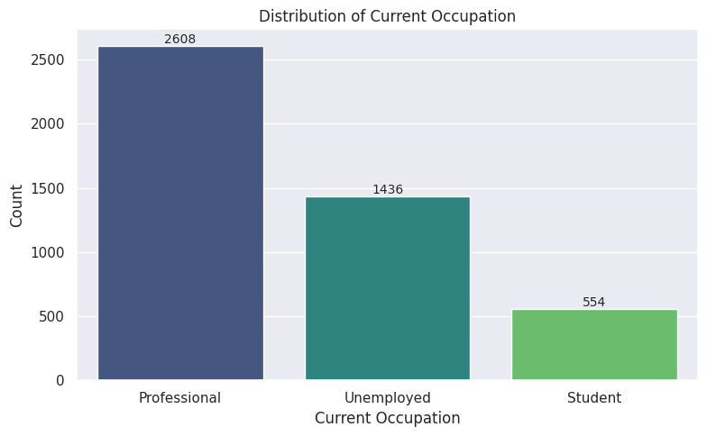

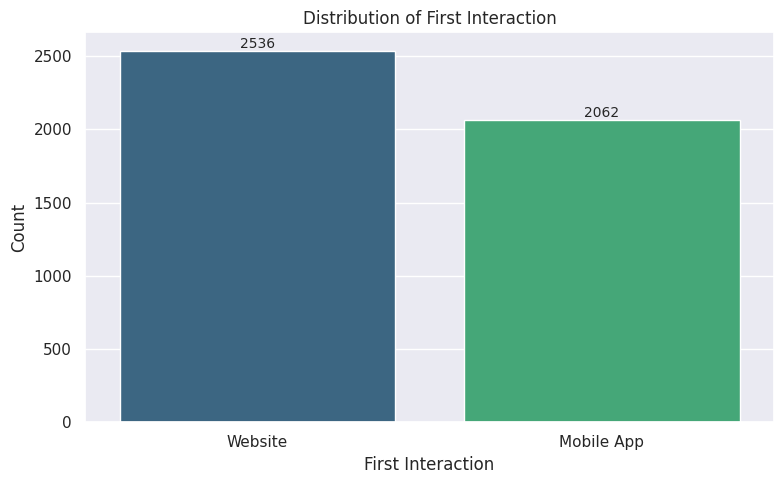

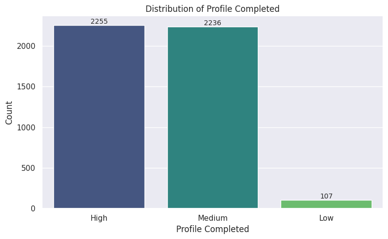

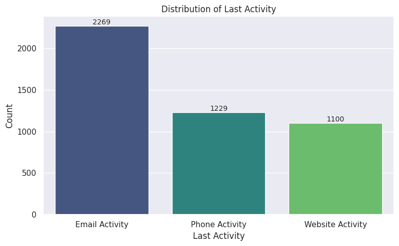

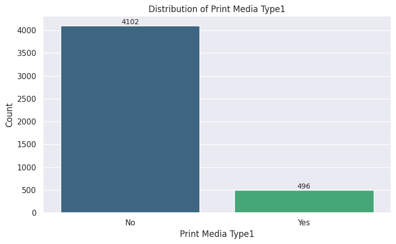

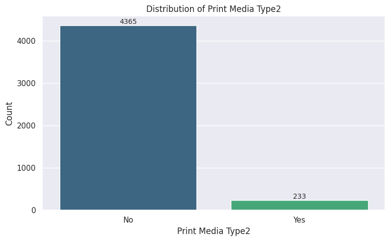

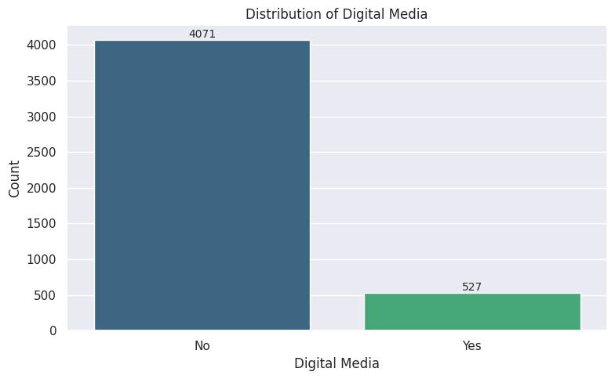

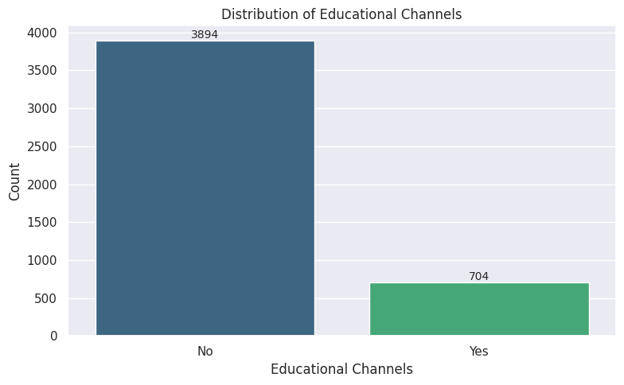

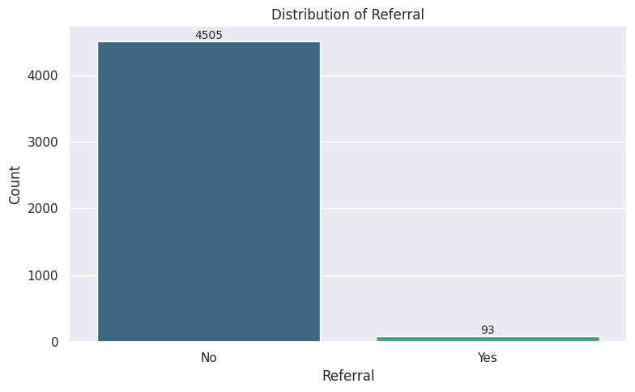

```python
# Plotting bar plots for categorical variables to visualize their distributions
for column in cat_col:
    plt.figure(figsize=(8, 5))
    ax = sns.countplot(data=df, x=column, order=df[column].value_counts().index, palette='viridis')
    plt.title(f'Distribution of {column.replace("_", " ").title()}')
    plt.xlabel(column.replace("_", " ").title())
    plt.ylabel('Count')

    # Add counts to barplot using ax.bar_label() with adjusted fontsize
    for container in ax.containers:
        ax.bar_label(container, fontsize=10)

    plt.tight_layout()
    plt.show()
```

##### **Observations on Categorical Variable Distributions**

Based on the value counts and the bar plots, we can observe the following distributions for the categorical variables:

- **current_occupation:** The majority of leads are 'Professional', followed by 'Unemployed', and then 'Student', as clearly shown in the bar plot.
- **first_interaction:** 'Website' is the most frequent first interaction method, slightly more common than 'Mobile App', visually confirmed by the bar plot.
- **profile_completed:** Leads are almost equally split between 'High' and 'Medium' profile completion, with a much smaller number having 'Low' completion, as seen in the bar plot.
- **last_activity:** 'Email Activity' is the most common last activity, followed by 'Phone Activity' and then 'Website Activity', visible in the bar plot.
- **print_media_type1, print_media_type2, digital_media, educational_channels, referral:** For all these binary (Yes/No) columns, the vast majority of leads fall into the 'No' category, indicating that most leads did not interact through these specific media channels or were not acquired through referrals. The bar plots clearly show the significant imbalance between the 'No' and 'Yes' categories for these features.

### **Bivariate and Multivariate Analysis**

#### **Correlation Heatmap of Numerical Data**

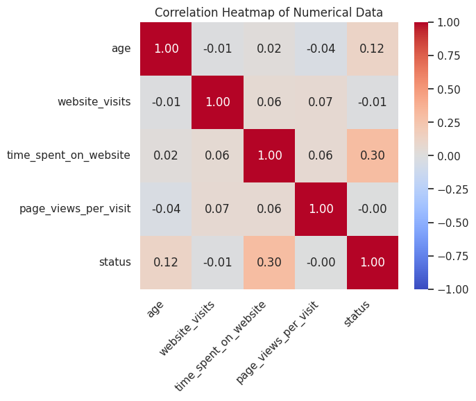

```
Top 3 Correlations with Status:
time_spent_on_website    0.301848
age                      0.122610
page_views_per_visit    -0.001293
Name: status, dtype: float64
```

```python
# Select numerical columns and the target variable for correlation analysis
numerical_cols_with_target = ['age', 'website_visits', 'time_spent_on_website', 'page_views_per_visit', 'status']

# Plotting the correlation heatmap for numerical data to visualize the relationships between numerical features and the target
plt.figure(figsize=(6, 5))
# Create a heatmap of the correlation matrix
sns.heatmap(df[numerical_cols_with_target].corr(), annot=True, fmt=".2f", cmap='coolwarm', vmin=-1, vmax=1) # Added vmax=1 for clarity

plt.xticks(rotation=45, ha='right')
plt.title('Correlation Heatmap of Numerical Data')
plt.show()

# Calculate correlations with the target variable 'status'
correlations_with_status = df[numerical_cols_with_target].corr()['status'].sort_values(ascending=False)

# Display the top 3 correlations with 'status' (excluding status correlating with itself)
print("\nTop 3 Correlations with Status:")
print(correlations_with_status[1:4]) # Exclude the correlation of status with itself (which is 1)
```

#### **Categorical Features vs. Target Variable (Status)**

In this section, we will explore the relationship between each categorical feature and the target variable `status` (lead conversion). By visualizing the distribution of converted and non-converted leads within each category, we can identify which categories are more or less likely to lead to conversion.

```python
# Define a function to plot categorical features against the target variable
def plot_categorical_vs_target(data, categorical_col, target_col):
    plt.figure(figsize=(8, 5))
    ax = sns.countplot(data=data, x=categorical_col, hue=target_col, palette='viridis')
    plt.title(f'Conversion Status by {categorical_col.replace("_", " ").title()}')
    plt.xlabel(categorical_col.replace("_", " ").title())
    plt.ylabel('Count')
    #plt.xticks(rotation=45, ha='right')
    plt.legend(title=target_col.capitalize(), labels=['Not Converted', 'Converted'], fontsize=10) # Assuming 0/1 encoding for status

    # Add counts to barplot using ax.bar_label() with adjusted fontsize
    for container in ax.containers:
        ax.bar_label(container, fontsize=10)

    plt.tight_layout()
    plt.show()
```

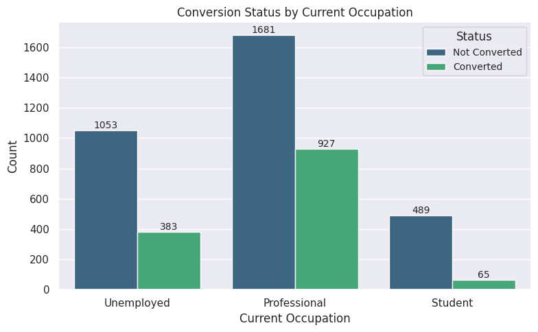

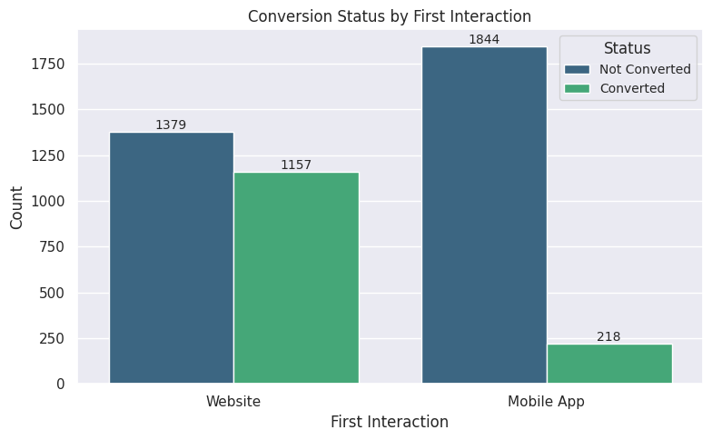

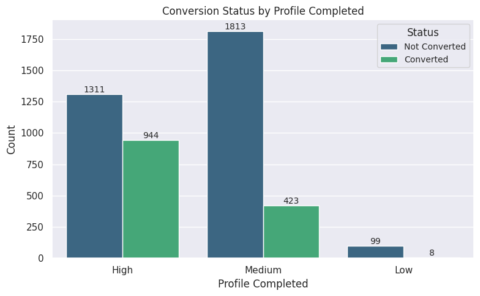

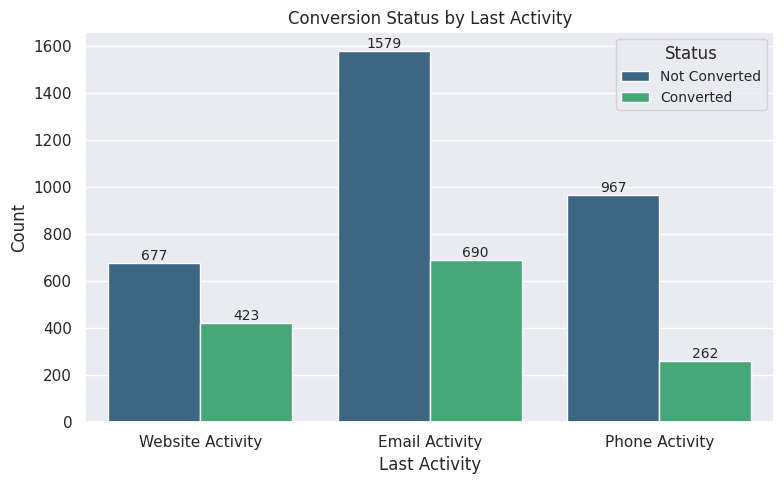

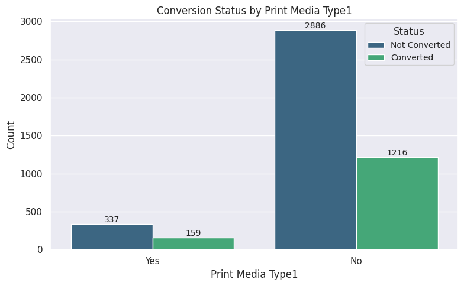

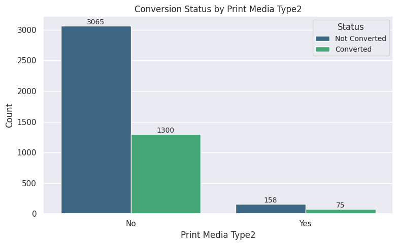

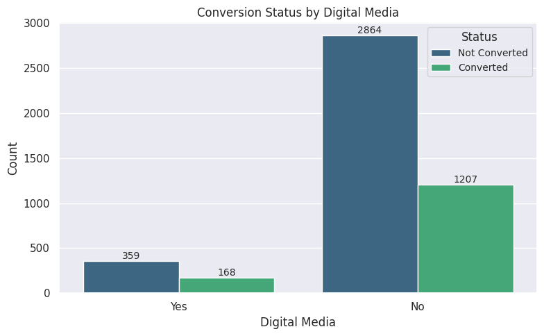

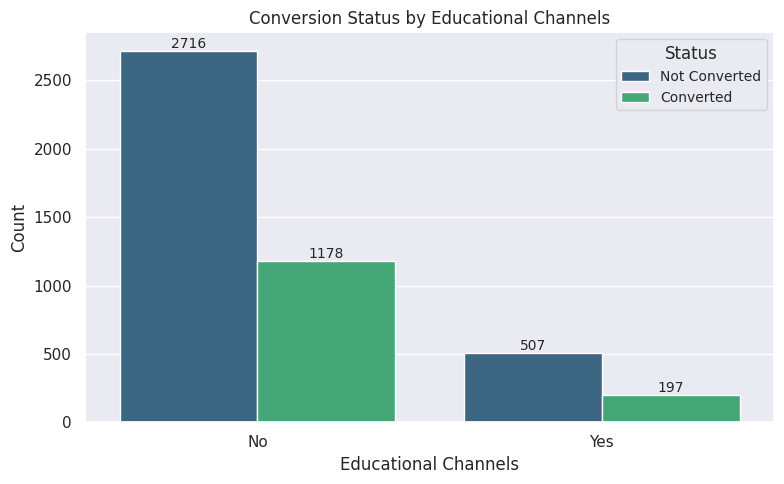

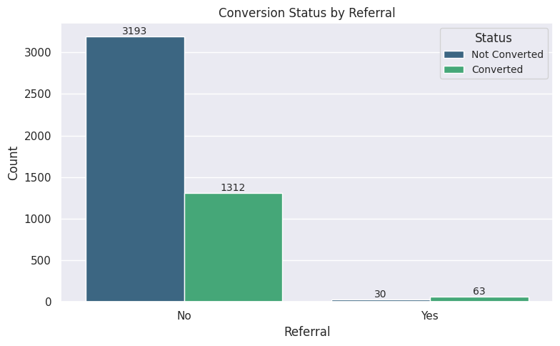

```python
# Loop through each categorical column and generate the plot against the target variable
# cat_col has been previously defined under 'Analyzing Categorical Features within Outlier Groups'
for column in cat_col:
    plot_categorical_vs_target(df, column, 'status')
```

```python
# Loop through each categorical column and print the counts and percentages of converted and non-converted leads per category
for column in cat_col:
    print(f"Conversion Status Counts and Percentages for {column.replace('_', ' ').title()}:")

    # Group by column and status, count occurrences, and unstack to get counts
    counts = df.groupby([column, 'status']).size().unstack(fill_value=0)

    # Calculate the sum of leads for each category
    counts['Total'] = counts[0] + counts[1]

    # Calculate percentages for converted and non-converted leads within each category
    counts['Not Converted (%)'] = (counts[0] / counts['Total']) * 100
    counts['Converted (%)'] = (counts[1] / counts['Total']) * 100

    # Display the counts and percentages, dropping the intermediate 'Total' column
    display(counts.drop(columns='Total'))

    print('-'*50) # Separator for readability
```

```
Conversion Status Counts and Percentages for Current Occupation:
```

| status current_occupation | 0 | 1 | Not Converted (%) | Converted (%) |
| --- | --- | --- | --- | --- |
| Professional | 1681 | 927 | 64.455521 | 35.544479 |
| Student | 489 | 65 | 88.267148 | 11.732852 |
| Unemployed | 1053 | 383 | 73.328691 | 26.671309 |

```
--------------------------------------------------
Conversion Status Counts and Percentages for First Interaction:
```

| status first_interaction | 0 | 1 | Not Converted (%) | Converted (%) |
| --- | --- | --- | --- | --- |
| Mobile App | 1844 | 218 | 89.427740 | 10.572260 |
| Website | 1379 | 1157 | 54.376972 | 45.623028 |

```
--------------------------------------------------
Conversion Status Counts and Percentages for Profile Completed:
```

| status profile_completed | 0 | 1 | Not Converted (%) | Converted (%) |
| --- | --- | --- | --- | --- |
| High | 1311 | 944 | 58.137472 | 41.862528 |
| Low | 99 | 8 | 92.523364 | 7.476636 |
| Medium | 1813 | 423 | 81.082290 | 18.917710 |

```
--------------------------------------------------
Conversion Status Counts and Percentages for Last Activity:
```

| status last_activity | 0 | 1 | Not Converted (%) | Converted (%) |
| --- | --- | --- | --- | --- |
| Email Activity | 1579 | 690 | 69.590128 | 30.409872 |
| Phone Activity | 967 | 262 | 78.681855 | 21.318145 |
| Website Activity | 677 | 423 | 61.545455 | 38.454545 |

```
--------------------------------------------------
Conversion Status Counts and Percentages for Print Media Type1:
```

| status print_media_type1 | 0 | 1 | Not Converted (%) | Converted (%) |
| --- | --- | --- | --- | --- |
| No | 2886 | 1216 | 70.355924 | 29.644076 |
| Yes | 337 | 159 | 67.943548 | 32.056452 |

```
--------------------------------------------------
Conversion Status Counts and Percentages for Print Media Type2:
```

| status print_media_type2 | 0 | 1 | Not Converted (%) | Converted (%) |
| --- | --- | --- | --- | --- |
| No | 3065 | 1300 | 70.217640 | 29.782360 |
| Yes | 158 | 75 | 67.811159 | 32.188841 |

```
--------------------------------------------------
Conversion Status Counts and Percentages for Digital Media:
```

| status digital_media | 0 | 1 | Not Converted (%) | Converted (%) |
| --- | --- | --- | --- | --- |
| No | 2864 | 1207 | 70.351265 | 29.648735 |
| Yes | 359 | 168 | 68.121442 | 31.878558 |

```
--------------------------------------------------
Conversion Status Counts and Percentages for Educational Channels:
```

| status educational_channels | 0 | 1 | Not Converted (%) | Converted (%) |
| --- | --- | --- | --- | --- |
| No | 2716 | 1178 | 69.748331 | 30.251669 |
| Yes | 507 | 197 | 72.017045 | 27.982955 |

```
--------------------------------------------------
Conversion Status Counts and Percentages for Referral:
```

| status referral | 0 | 1 | Not Converted (%) | Converted (%) |
| --- | --- | --- | --- | --- |
| No | 3193 | 1312 | 70.876804 | 29.123196 |
| Yes | 30 | 63 | 32.258065 | 67.741935 |

##### **General Observation of Categorical Features vs. Target Variable (Status)**

Based on the bivariate analysis of categorical features against the target variable (`status`) and the calculated conversion percentages:

- **Current Occupation:** 'Professional' leads have the highest conversion rate at approximately **35.5%**, compared to 'Unemployed' (around **26.7%**) and 'Student' (around **11.7%**). This shows a significant difference in conversion likelihood based on occupation.
- **First Interaction:** Leads whose first interaction was through the **Website** have a much higher conversion rate (around **45.6%**) compared to those who first interacted through the **Mobile App** (around **10.6%**).
- **Profile Completed:** Leads with **'High'** profile completion have the highest conversion rate (around **41.9%**), followed by 'Medium' (around **18.9%**), and **'Low'** profile completion has a very low conversion rate (around **7.5%**).
- **Last Activity:** 'Website Activity' (around **38.5%** converted) and 'Email Activity' (around **30.4%** converted) show higher conversion rates compared to 'Phone Activity' (around **21.3%** converted).
- **Print Media (Type1 & Type2), Digital Media, Educational Channels, Referral:** While the absolute numbers of leads from these channels are generally lower, some show notable conversion rates:
  - `Referral` leads have a very high conversion rate (around **67.7%**), although the total number of referred leads is small.
  - `Print_media_type1` (around **32.1%** converted), `Print_media_type2` (around **32.2%** converted), and `Digital_media` (around **31.9%** converted) have conversion rates slightly above the overall average (~29.9%), but the majority of leads did not come through these channels.
  - `Educational_channels` have a conversion rate slightly below the overall average (around **28.0%** converted).

Overall, factors like being a 'Professional' lead, having a 'High' profile completion, and initially interacting through the 'Website' or having 'Website Activity' as the last activity are strongly associated with higher conversion rates. Referral is also a high-converting channel despite low volume. Conversely, being a 'Student', a 'Mobile App' first interaction, or having 'Low' profile completion are associated with lower conversion rates.

#### **Numerical Features vs. Conversion Status**

In this section, we visualize the relationship between each numerical feature and the conversion status (`status`) using box plots to compare the distributions for converted and non-converted leads.

```python
# Define a function to plot a numerical feature against a categorical feature (e.g., the target)
def plot_numerical_vs_categorical(data, numerical_col, categorical_col):
    plt.figure(figsize=(12, 4))
    sns.boxplot(data=data, x=numerical_col, y=categorical_col, palette='viridis', orient='h', showmeans=True,
                meanprops={"markerfacecolor":"red", "markeredgecolor":"black", "markersize":"8"}) # Added meanprops for color

    plt.title(f'{numerical_col.replace("_", " ").title()} vs. {categorical_col.replace("_", " ").title()}')
    plt.xlabel(numerical_col.replace("_", " ").title()) # Numerical feature on x-axis
    plt.ylabel('Conversion Status') # Categorical feature on y-axis
    # We need to set yticks for the categorical labels.
    plt.yticks([0, 1], ['Not Converted', 'Converted']) # Set y-axis tick labels for the categories
    plt.tight_layout()
    plt.show()
```

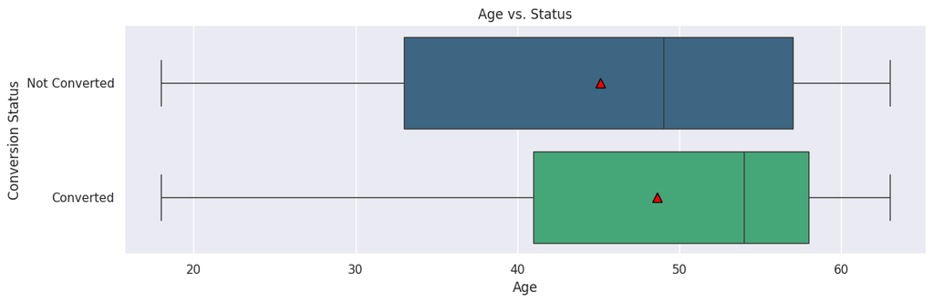

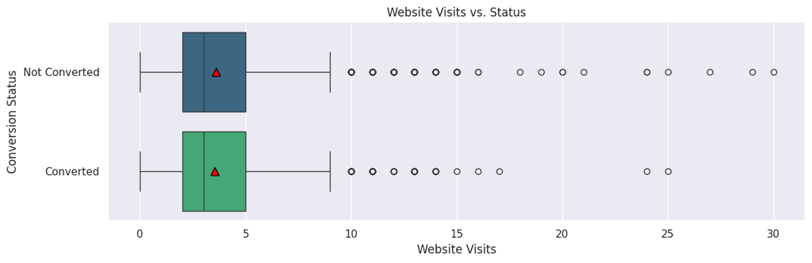

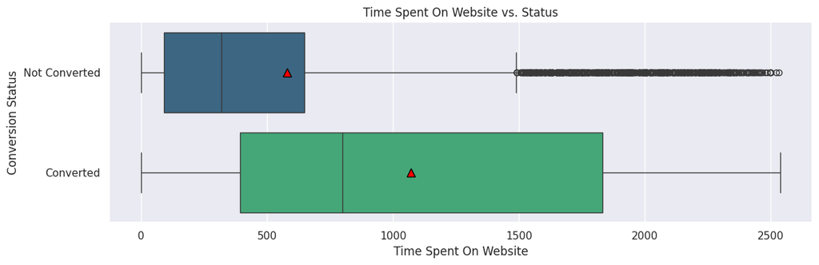

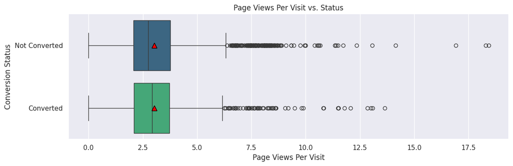

```python
# List of numerical columns to plot against the target variable
numerical_cols = ['age', 'website_visits', 'time_spent_on_website', 'page_views_per_visit']

# Loop through each numerical column and generate the plot against the target variable
for column in numerical_cols:
    plot_numerical_vs_categorical(df, column, 'status')
```

##### **Observations on Numerical Features vs. Conversion Status**

Based on the box plots visualizing the relationship between numerical features and conversion status:

- **Age vs. Status:**
  - Converted leads (Status 1) tend to be slightly older than non-converted leads (Status 0). The median age for converted leads appears higher than for non-converted leads. Both groups show a similar spread in age.
- **Website Visits vs. Status:**
  - The distributions of website visits for converted and non-converted leads are quite similar. Both groups have a low median number of visits, and both show several outliers with a high number of visits. There isn't a clear distinction in the typical number of website visits between converted and non-converted leads based on these box plots.
- **Time Spent on Website vs. Status:**
  - Converted leads (Status 1) spend significantly more time on the website compared to non-converted leads (Status 0). The median and mean time spent are much higher for converted leads. The distribution for converted leads is shifted towards higher values and appears more spread out on the higher end. This aligns with the positive correlation observed earlier.
- **Page Views per Visit vs. Status:**
  - Similar to website visits, the distributions of page views per visit for converted and non-converted leads are quite similar. Both groups have low median page views per visit and show outliers on the higher end. There isn't a strong distinction in the typical average page views per visit between converted and non-converted leads based on these box plots.

These visualizations reinforce that `time_spent_on_website` appears to be the most important numerical factor distinguishing converted from non-converted leads, with converted leads spending considerably more time on the website. Age shows a weaker difference, and website visits and page views per visit don't show a clear visual separation between the two status groups.

#### **Correlation Analysis with Encoded Categorical Features**

To explore the linear relationships between categorical features and other variables, including the target variable, we will encode the categorical features using one-hot encoding and then generate a correlation heatmap of the expanded dataset.

|  | age | website_visits | time_spent_on_website | page_views_per_visit | status | current_occupation_Student | current_occupation_Unemployed | first_interaction_Website | profile_completed_Low | profile_completed_Medium | last_activity_Phone Activity | last_activity_Website Activity | print_media_type1_Yes | print_media_type2_Yes | digital_media_Yes | educational_channels_Yes | referral_Yes |
| --- | --- | --- | --- | --- | --- | --- | --- | --- | --- | --- | --- | --- | --- | --- | --- | --- | --- |
| 0 | 57 | 7 | 1639 | 1.861 | 1 | False | True | True | False | False | False | True | True | False | True | False | False |
| 1 | 56 | 2 | 83 | 0.320 | 0 | False | False | False | False | True | False | True | False | False | False | True | False |
| 2 | 52 | 3 | 330 | 0.074 | 0 | False | False | True | False | True | False | True | False | False | True | False | False |
| 3 | 53 | 4 | 464 | 2.057 | 1 | False | True | True | False | False | False | True | False | False | False | False | False |
| 4 | 23 | 4 | 600 | 16.914 | 0 | True | False | True | False | False | False | False | False | False | False | False | False |

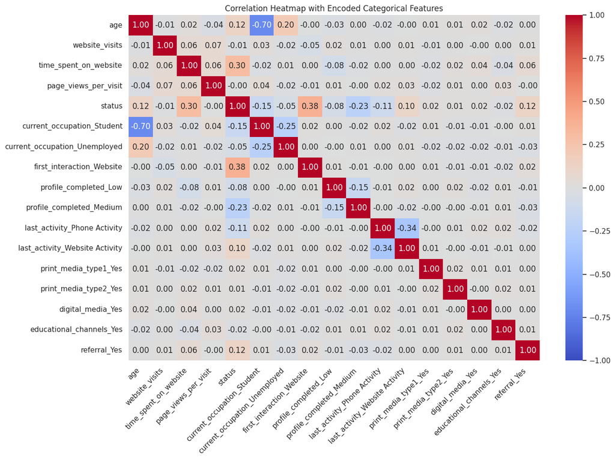

```
Top 5 Positive Correlations with Status:
first_interaction_Website         0.380746
time_spent_on_website             0.301848
age                               0.122610
referral_Yes                      0.118742
last_activity_Website Activity    0.104725
Name: status, dtype: float64

Top 5 Negative Correlations with Status:
current_occupation_Unemployed   -0.047587
profile_completed_Low           -0.075612
last_activity_Phone Activity    -0.113269
current_occupation_Student      -0.146902
Name: status, dtype: float64
```

```python
# Perform one-hot encoding on the selected categorical columns
df_encoded = pd.get_dummies(df, columns=cat_col, drop_first=True) # drop_first=True to avoid multicollinearity

# Display the first few rows of the encoded dataframe to verify the change
display(df_encoded.head())

# Generate the correlation heatmap for the encoded dataframe including the target variable
plt.figure(figsize=(14, 10))
sns.heatmap(df_encoded.corr(), annot=True, fmt=".2f", cmap='coolwarm', vmin=-1, vmax=1)
plt.title('Correlation Heatmap with Encoded Categorical Features')
plt.xticks(rotation=45, ha='right')
plt.yticks(rotation=0)
plt.tight_layout()
plt.show()

# Calculate correlations with the target variable 'status' using the encoded dataframe
correlations_with_status_encoded = df_encoded.corr()['status'].sort_values(ascending=False)

# Display the top 5 positive correlations with 'status' (excluding status correlating with itself)
print("\nTop 5 Positive Correlations with Status:")
print(correlations_with_status_encoded[1:6]) # Exclude the correlation of status with itself (which is 1)

# Display the top 5 negative correlations with 'status'
print("\nTop 5 Negative Correlations with Status:")
print(correlations_with_status_encoded[-5:-1]) # Exclude the last element which is the weakest negative correlation
```

##### **Observations from Correlation Heatmap with Encoded Categorical Features**

Based on the correlation heatmap including the one-hot encoded categorical features and the printed top correlations with 'status':

Overall, this correlation analysis with encoded features quantifies the linear relationships and reinforces the insights gained from the bivariate plots, highlighting key features and categories associated with higher and lower conversion likelihood.

### **Summary of Exploratory Data Analysis (EDA)**

Based on the comprehensive Exploratory Data Analysis performed, the following key insights have been gathered regarding the ExtraaLearn leads dataset and factors potentially influencing conversion (`status`):

#### **Data Characteristics:**

- The dataset contains 4598 unique lead records after initial cleaning (dropping 'ID' and duplicates).
- There are no missing values.
- Features include a mix of numerical (age, website interaction metrics) and categorical variables.

#### **Univariate Analysis:**

- Numerical features like `time_spent_on_website`, `website_visits`, and `page_views_per_visit` are right-skewed and show potential outliers, indicating a large number of leads with low activity and a smaller group with very high activity. A log transformation (`np.log1p`) is planned to address this for modeling.
- Categorical features show varying distributions, with 'Professional' being the most common occupation, 'Website' the most common first interaction, and 'High'/'Medium' the most common profile completion levels. Most leads did not engage through specific media channels or referrals, although 'Referral' shows a high conversion rate despite low volume.

#### **Bivariate Analysis:**

- **Numerical vs. Target:** `time_spent_on_website` shows the strongest positive correlation with `status` (0.30), and box plots confirm that converted leads generally spend significantly more time on the website. `Age` has a weak positive correlation (0.12), while `website_visits` and `page_views_per_visit` show very weak correlations.
- **Categorical vs. Target:**
  - `Professional` leads and those with 'High' profile completion have notably higher conversion rates (around 35.5% and 41.9% respectively).
  - `Website` as the first interaction method is associated with a much higher conversion rate (around 45.6%) compared to `Mobile App` (around 10.6%).
  - `Website Activity` and 'Email Activity' as the last activity show higher conversion likelihood than 'Phone Activity'.
  - `Referral` has a very high conversion rate (around 67.7%), highlighting its effectiveness despite being a less frequent source. While only a small number of leads (93) came through this channel, their conversion rate was significantly higher than the overall conversion rate.
  - Conversely, being a `Student`, having `Low` profile completion, or `Mobile App` as the first interaction are associated with lower conversion rates.

#### **Outlier Analysis:**

- While a small percentage of leads are statistical outliers in `website_visits` and `page_views_per_visit`, they don't appear to be data errors and show varied characteristics and conversion outcomes, reinforcing the decision to transform rather than remove them.

These findings provide valuable insights for selecting features and building a predictive model to identify leads most likely to convert.

## **Data Preprocessing**

In this section, we will prepare the cleaned and analyzed data for input into machine learning models. This will involve applying transformations to address skewness and outliers in numerical features, encoding categorical variables, and splitting the data into training and testing sets.

### **Applying Log Transformation (np.log1p)**

Based on our univariate analysis, the `website_visits`, `time_spent_on_website`, and `page_views_per_visit` columns are right-skewed and contain outliers. To address this and make the data more suitable for many machine learning models, we will apply the `np.log1p` transformation to these columns. This transformation is useful for positively skewed data, especially when it includes zero values (log(1+x)).

|  | age | website_visits | time_spent_on_website | page_views_per_visit | status | current_occupation_Student | current_occupation_Unemployed | first_interaction_Website | profile_completed_Low | profile_completed_Medium | last_activity_Phone Activity | last_activity_Website Activity | print_media_type1_Yes | print_media_type2_Yes | digital_media_Yes | educational_channels_Yes | referral_Yes |
| --- | --- | --- | --- | --- | --- | --- | --- | --- | --- | --- | --- | --- | --- | --- | --- | --- | --- |
| 0 | 57 | 2.079442 | 7.402452 | 1.051171 | 1 | False | True | True | False | False | False | True | True | False | True | False | False |
| 1 | 56 | 1.098612 | 4.430817 | 0.277632 | 0 | False | False | False | False | True | False | True | False | False | False | True | False |
| 2 | 52 | 1.386294 | 5.802118 | 0.071390 | 0 | False | False | True | False | True | False | True | False | False | True | False | False |
| 3 | 53 | 1.609438 | 6.142037 | 1.117434 | 1 | False | True | True | False | False | False | True | False | False | False | False | False |
| 4 | 23 | 1.609438 | 6.398595 | 2.885583 | 0 | True | False | True | False | False | False | False | False | False | False | False | False |

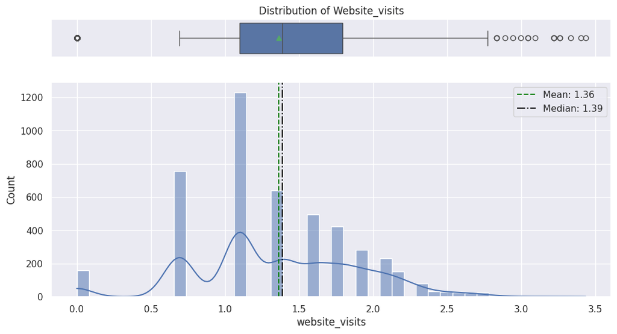

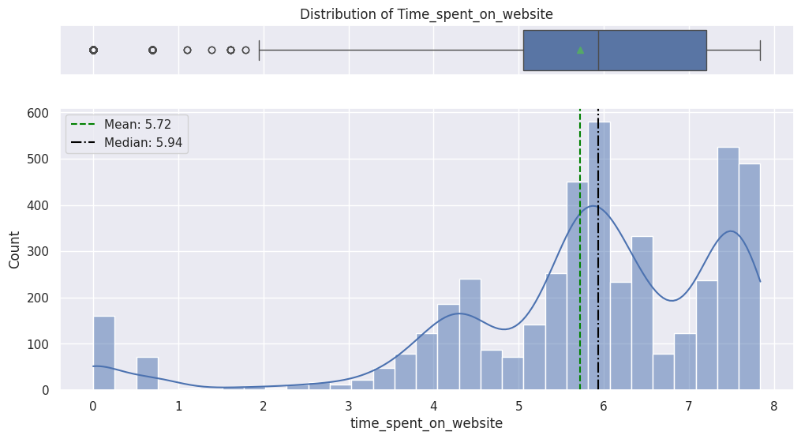

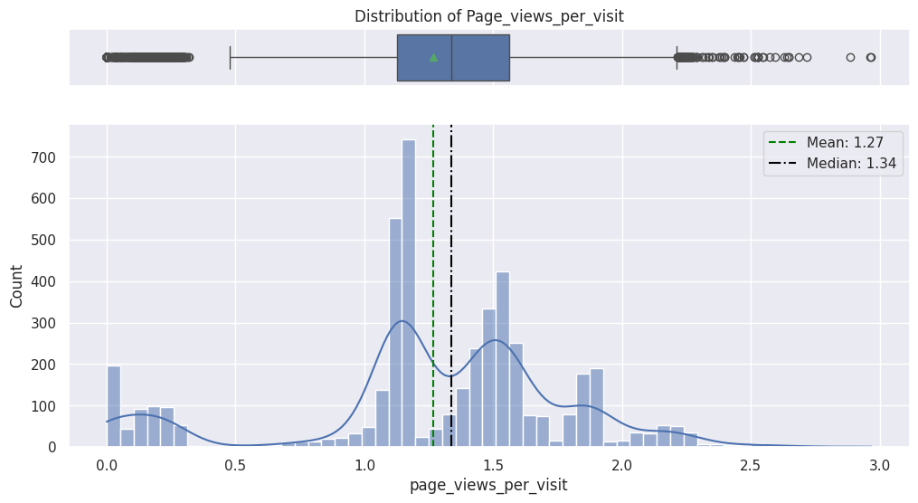

```python
# Apply log transformation (np.log1p) to the specified columns within df_encoded
columns_to_transform = ['website_visits', 'time_spent_on_website', 'page_views_per_visit']
for col in columns_to_transform:
    df_encoded[col] = np.log1p(df_encoded[col])

# Rename df_encoded to df_transform to indicate it now has both encoded and transformed features
df_transform = df_encoded.copy() # Create a copy with the new name
del df_encoded # Delete the old name to avoid confusion

# Display the first few rows of the transformed dataframe
display(df_transform.head())

# Optionally, you can visualize the distributions again to see the effect of the transformation
for col in columns_to_transform:
  hist_box(df_transform, col)
```

#### **Observation after Applying Log Transformation**

After applying the `np.log1p` transformation to the `website_visits`, `time_spent_on_website`, and `page_views_per_visit` columns within the DataFrame that is now named `df_transform`:

- The values in these columns have been transformed (e.g., original integer counts/seconds are now represented by their log(1+x) values).
- This transformation **has reduced the right-skewness** and the impact of outliers in these features. The transformed distributions are more symmetrical, and the mean and median are closer together, making the data more suitable for linear models.
- The `df_transform.head()` output shows the updated, transformed values in these columns.

### Creating New Features

Based on the exploratory data analysis, we will create new features by combining existing ones. These new features aim to capture more nuanced aspects of lead interaction and engagement, which might improve the predictive power of our models.

Specifically, we will create:

- **Interaction Score:** A combined metric of website visits, time spent, and page views per visit to represent overall website interaction.
- **Media Interaction:** A sum of binary flags indicating interaction through print and digital media channels.
- **Website Engagement:** A feature reflecting the combined effect of website visits and time spent.

```python
# Create a new column 'interaction_score' as the sum of transformed website interaction metrics
df_transform['interaction_score'] = df_transform['website_visits'] + df_transform['time_spent_on_website'] + df_transform['page_views_per_visit']

# Create a new column 'media_interaction' by summing the binary media interaction columns
df_transform['media_interaction'] = df_transform['print_media_type1_Yes'] + df_transform['print_media_type2_Yes'] + df_transform['digital_media_Yes']

# Create a new column 'website_engagement' by multiplying transformed website visits and time spent
df_transform['website_engagement'] = df_transform['website_visits'] * df_transform['time_spent_on_website']

# Display the first 5 rows of the dataframe to inspect the newly created features
display(df_transform.head())
```

|  | age | website_visits | time_spent_on_website | page_views_per_visit | status | current_occupation_Student | current_occupation_Unemployed | first_interaction_Website | profile_completed_Low | profile_completed_Medium | last_activity_Phone Activity | last_activity_Website Activity | print_media_type1_Yes | print_media_type2_Yes | digital_media_Yes | educational_channels_Yes | referral_Yes | interaction_score | media_interaction | website_engagement |
| --- | --- | --- | --- | --- | --- | --- | --- | --- | --- | --- | --- | --- | --- | --- | --- | --- | --- | --- | --- | --- |
| 0 | 57 | 2.079442 | 7.402452 | 1.051171 | 1 | False | True | True | False | False | False | True | True | False | True | False | False | 10.533064 | True | 15.392965 |
| 1 | 56 | 1.098612 | 4.430817 | 0.277632 | 0 | False | False | False | False | True | False | True | False | False | False | True | False | 5.807061 | False | 4.867750 |
| 2 | 52 | 1.386294 | 5.802118 | 0.071390 | 0 | False | False | True | False | True | False | True | False | False | True | False | False | 7.259803 | True | 8.043444 |
| 3 | 53 | 1.609438 | 6.142037 | 1.117434 | 1 | False | True | True | False | False | False | True | False | False | False | False | False | 8.868909 | False | 9.885228 |
| 4 | 23 | 1.609438 | 6.398595 | 2.885583 | 0 | True | False | True | False | False | False | False | False | False | False | False | False | 10.893615 | False | 10.298141 |

#### **Observation on Feature Engineering**

After executing the feature engineering code, the following new features have been successfully created and added to the `df_transform` DataFrame:

- **`interaction_score`**: A combined metric of website visits, time spent, and page views per visit.
- **`media_interaction`**: A sum of binary flags indicating interaction through print and digital media channels.
- **`website_engagement`**: A feature reflecting the combined effect of website visits and time spent.

These new features are now part of the dataset that will be used for model training and evaluation.

### **Min-Max Scaling**

We will apply Min-Max scaling to all numerical features to ensure they are on a similar scale. This is important for many machine learning algorithms, especially those that are sensitive to the magnitude of features. Min-Max scaling transforms features by scaling each feature to a given range, typically between 0 and 1.

```python
# Identify numerical columns (including the transformed ones)
numerical_cols = ['age', 'website_visits', 'time_spent_on_website', 'page_views_per_visit', 'interaction_score', 'media_interaction', 'website_engagement']

# Initialize the MinMaxScaler
scaler = MinMaxScaler()

# Apply Min-Max scaling to the numerical columns in df_transform
# We fit and transform on the entire df_transform before splitting to avoid data leakage
df_transform[numerical_cols] = scaler.fit_transform(df_transform[numerical_cols])

# Display the first few rows of the scaled dataframe
display(df_transform.head())
```

|  | age | website_visits | time_spent_on_website | page_views_per_visit | status | current_occupation_Student | current_occupation_Unemployed | first_interaction_Website | profile_completed_Low | profile_completed_Medium | last_activity_Phone Activity | last_activity_Website Activity | print_media_type1_Yes | print_media_type2_Yes | digital_media_Yes | educational_channels_Yes | referral_Yes | interaction_score | media_interaction | website_engagement |
| --- | --- | --- | --- | --- | --- | --- | --- | --- | --- | --- | --- | --- | --- | --- | --- | --- | --- | --- | --- | --- |
| 0 | 0.866667 | 0.605547 | 0.944295 | 0.354285 | 1 | False | True | True | False | False | False | True | True | False | True | False | False | 0.823525 | 1.0 | 0.641939 |
| 1 | 0.844444 | 0.319923 | 0.565218 | 0.093572 | 0 | False | False | False | False | True | False | True | False | False | False | True | False | 0.454023 | 0.0 | 0.203002 |
| 2 | 0.755556 | 0.403698 | 0.740148 | 0.024061 | 0 | False | False | True | False | True | False | True | False | False | True | False | False | 0.567606 | 1.0 | 0.335439 |
| 3 | 0.777778 | 0.468679 | 0.783510 | 0.376618 | 1 | False | True | True | False | False | False | True | False | False | False | False | False | 0.693413 | 0.0 | 0.412248 |
| 4 | 0.111111 | 0.468679 | 0.816238 | 0.972551 | 0 | True | False | True | False | False | False | False | False | False | False | False | False | 0.851714 | 0.0 | 0.429468 |

```python
# Display descriptive statistics for the dataframe after feature engineering and MInMaxScaling
print("Summary statistics after Feature Engineering and MinMax Scaling:")
display(df_transform.describe().T)
```

```
Summary statistics after Feature Engineering and MinMax Scaling:
```

|  | count | mean | std | min | 25% | 50% | 75% | max |
| --- | --- | --- | --- | --- | --- | --- | --- | --- |
| age | 4598.0 | 0.626205 | 0.292462 | 0.0 | 0.400000 | 0.733333 | 0.866667 | 1.0 |
| website_visits | 4598.0 | 0.396348 | 0.164464 | 0.0 | 0.319923 | 0.403698 | 0.521772 | 1.0 |
| time_spent_on_website | 4598.0 | 0.729714 | 0.227038 | 0.0 | 0.644389 | 0.757254 | 0.918785 | 1.0 |
| page_views_per_visit | 4598.0 | 0.427338 | 0.180803 | 0.0 | 0.379144 | 0.450743 | 0.525792 | 1.0 |
| status | 4598.0 | 0.299043 | 0.457889 | 0.0 | 0.000000 | 0.000000 | 1.000000 | 1.0 |
| interaction_score | 4598.0 | 0.652787 | 0.176076 | 0.0 | 0.591021 | 0.681424 | 0.764658 | 1.0 |
| media_interaction | 4598.0 | 0.248151 | 0.431987 | 0.0 | 0.000000 | 0.000000 | 0.000000 | 1.0 |
| website_engagement | 4598.0 | 0.337916 | 0.166522 | 0.0 | 0.216295 | 0.334772 | 0.443074 | 1.0 |

#### Observation on Summary Statistics after Feature Engineering and MinMax Scaling

Based on the descriptive statistics of the `df_transform` DataFrame:

- All numerical features, including engineered ones, are now scaled between 0 and 1.
- Transformed website interaction features show reduced skewness.
- New features like `interaction_score`, `media_interaction`, and `website_engagement` provide combined metrics of lead activity.
- The conversion rate (`status` mean ~0.299) remains consistent.

Overall, the data is successfully preprocessed and augmented with new features, ready for modeling.

### **Splitting Data into Training and Testing Sets**

Before building the machine learning models, we need to split the data into training and testing sets. This allows us to train the model on a portion of the data and evaluate its performance on unseen data to get a realistic estimate of its generalization ability. We will use a test size of 20% (an 80/20 split), which is a common and generally recommended split for datasets of this size, providing a good balance between training set size and test set size for reliable evaluation.

```python
# Separate features (X) and target variable (y)
X = df_transform.drop('status', axis=1) # Exclude 'Status' because it's the target
y = df_transform['status']

# Split the data into training and testing sets (80% train, 20% test)
X_train, X_test, y_train, y_test = train_test_split(X, y, test_size=0.2, random_state=42)

print("Shape of X_train:", X_train.shape)
print("Shape of X_test:", X_test.shape)
print("Shape of y_train:", y_train.shape)
print("Shape of y_test:", y_test.shape)
```

```
Shape of X_train: (3678, 19)
Shape of X_test: (920, 19)
Shape of y_train: (3678,)
Shape of y_test: (920,)
```

### **Summary of Data Preprocessing**

In this section, we performed several key data preprocessing steps to prepare the data for machine learning models:

1. **Handling Irrelevant Columns and Duplicates:** We removed the 'ID' column and identified and deleted duplicate rows to ensure data integrity and relevance.
2. **Categorical Feature Encoding:** Used one-hot encoding to convert categorical variables into a numerical format suitable for modeling.
3. **Log Transformation:** Applied `np.log1p` to the right-skewed numerical features (`website_visits`, `time_spent_on_website`, `page_views_per_visit`) to address skewness and the impact of outliers.
4. **Feature Engineering:** Created new features (`interaction_score`, `media_interaction`, `website_engagement`) by combining existing ones to capture more nuanced aspects of lead behavior.
5. **Min-Max Scaling:** Applied Min-Max scaling to all numerical features (including the transformed and engineered ones) to bring them to a comparable range between 0 and 1.
6. **Splitting Data:** Split the data into training and testing sets.

These steps have transformed the raw data into a clean and structured format, with features that are appropriately scaled and encoded, and split for model training, making the dataset ready for the model building phase.

## **Model Building**

In this section, we will build machine learning models to predict lead conversion (`status`). We will train several classification models on the training data and evaluate their performance.

### **Helper Functions for Model Evaluation Visualization**

#### **Display Model Comparison Table**

To facilitate the comparison and visualization of model performance metrics, we define a helper function that takes the dictionary containing model results and generates a pandas DataFrame summarizing key performance metrics for each model. It then sorts this table by the test ROC AUC in descending order to easily identify the top-performing models and displays the table.

```python
def display_model_comparison_table(model_results):
    """
    Generates and displays a sorted DataFrame of model performance metrics.

    Args:
        model_results (dict): A dictionary containing performance results for each model.

    Returns:
        pd.DataFrame: The sorted DataFrame of model performance metrics.
    """
    summary_results = {}

    for model_name, results in model_results.items():
        summary_results[model_name] = {
            'Accuracy (Train)': results['Training Report']['accuracy'],
            'Precision (Train - Converted)': results['Training Report']['1']['precision'],
            'Recall (Train - Converted)': results['Training Report']['1']['recall'],
            'F1-score (Train - Converted)': results['Training Report']['1']['f1-score'],
            'ROC AUC (Train)': results['Training ROC AUC'],
            'Accuracy (Test)': results['Testing Report']['accuracy'],
            'Precision (Test - Converted)': results['Testing Report']['1']['precision'],
            'Recall (Test - Converted)': results['Testing Report']['1']['recall'],
            'F1-score (Test - Converted)': results['Testing Report']['1']['f1-score'],
            'ROC AUC (Test)': results['Testing ROC AUC'],
            'Training Time (s)': results['Training Time (s)'],
            'Prediction Time (s)': results['Testing Prediction Time (s)']
        }

    # Convert the summary results dictionary to a DataFrame
    results_df = pd.DataFrame(summary_results).T

    # Sort the DataFrame by 'ROC AUC (Test)' in descending order
    results_df_sorted = results_df.sort_values(by='ROC AUC (Test)', ascending=False)

    # Display the results table
    print("Model Comparison Table (Sorted by Test ROC AUC):")
    display(results_df_sorted)

    # Return the sorted DataFrame
    return results_df_sorted
```

#### **Display Confusion Matrices**

To help visualize the performance of our classification models, we define a helper function to plot confusion matrices for the top performing models. Confusion matrices provide a detailed breakdown of correct and incorrect predictions, showing true positives, true negatives, false positives, and false negatives.

```python
def plot_top_n_confusion_matrices(model_results, results_df_sorted, n):
    """
    Displays confusion matrices for the top N models based on the sorted results DataFrame.

    Args:
        model_results (dict): A dictionary containing performance results for each model.
        results_df_sorted (pd.DataFrame): The sorted DataFrame of model performance metrics.
        n (int): The number of top models to display confusion matrices for.
    """
    # Get the names of the top N models
    top_n_models = results_df_sorted.head(n).index.tolist()

    # Print the main title before displaying the matrices
    print(f"\n--- Confusion Matrices for Top {n} Models (Based on Test ROC AUC) ---")


    # Display confusion matrices for the top N models
    for model_name in top_n_models:
      if model_name in model_results: # Check if the model exists in model_results
            results = model_results[model_name]

            # Create a figure with two subplots (one for training, one for testing)
            fig, axes = plt.subplots(1, 2, figsize=(10, 4)) # 1 row, 2 columns
            fig.suptitle(f'Confusion Matrices for {model_name}', y=1.02) # Main title for the figure, adjusted y position

            # Training Confusion Matrix
            cm_train = np.array(results['Training Confusion Matrix'])
            sns.heatmap(cm_train, annot=True, fmt='d', cmap='Blues', xticklabels=['Not Converted', 'Converted'], yticklabels=['Not Converted', 'Converted'], ax=axes[0])
            axes[0].set_title(f'{model_name} - Training Confusion Matrix') # Subtitle for the training matrix
            axes[0].set_xlabel('Predicted Label')
            axes[0].set_ylabel('True Label')

            # Testing Confusion Matrix
            cm_test = np.array(results['Testing Confusion Matrix'])
            sns.heatmap(cm_test, annot=True, fmt='d', cmap='Blues', xticklabels=['Not Converted', 'Converted'], yticklabels=['Not Converted', 'Converted'], ax=axes[1])
            axes[1].set_title(f'{model_name} - Testing Confusion Matrix') # Subtitle for the testing matrix
            axes[1].set_xlabel('Predicted Label')
            axes[1].set_ylabel('True Label')


            plt.tight_layout()
            plt.show()
```

#### **Display Feature Importance (Tree-Based Models)**

To easily visualize the feature importance for our tree-based models (Decision Tree and Random Forest), we define a helper function that takes the trained model, feature names, and a model name as input and displays the feature importances.

```python
def display_feature_importance(model, feature_names, model_name, top_n=10):
    """
    Calculates and displays feature importance for a tree-based model.

    Args:
        model: Trained tree-based model (e.g., DecisionTreeClassifier, RandomForestClassifier).
        feature_names (list): List of feature names (column names of X_train).
        model_name (str): Name of the model for the title.
        top_n (int): Number of top features to display and visualize.
    """
    # Get feature importances
    feature_importances = model.feature_importances_

    # Create a pandas Series for easier handling and visualization
    feature_importance_series = pd.Series(feature_importances, index=feature_names)

    # Sort feature importances in descending order
    sorted_feature_importances = feature_importance_series.sort_values(ascending=False)

    # Display the sorted feature importances
    print(f"Feature Importances ({model_name}):")
    display(sorted_feature_importances)

    # Visualize the top N feature importances
    plt.figure(figsize=(9, 5))
    sorted_feature_importances.head(top_n).plot(kind='barh')
    plt.title(f'Top {top_n} Feature Importances ({model_name})')
    plt.xlabel('Importance')
    plt.ylabel('Feature')
    plt.gca().invert_yaxis()  # Invert y-axis to show the most important feature at the top
    plt.show()
```

### **Logistic Regression Model**

We will start by building a Logistic Regression model as a baseline. Logistic Regression is a simple yet effective linear model for binary classification.

```python
# Initialize Logistic Regression model
log_reg = LogisticRegression(random_state=42)

# Train the model and measure training time
start_time = time.time()
log_reg.fit(X_train, y_train)
training_time_lr = time.time() - start_time

# Make predictions on the training and testing sets and measure prediction time
start_time = time.time()
y_train_pred_lr = log_reg.predict(X_train)
train_prediction_time_lr = time.time() - start_time

start_time = time.time()
y_test_pred_lr = log_reg.predict(X_test)
test_prediction_time_lr = time.time() - start_time

# Get predicted probabilities for the testing set
y_test_proba_lr = log_reg.predict_proba(X_test)[:, 1]


# Evaluate the model
test_report_lr = classification_report(y_test, y_test_pred_lr, output_dict=True)
test_roc_auc_lr = roc_auc_score(y_test, y_test_proba_lr)


# Store results in a dictionary
model_results = {}
model_results['Logistic Regression'] = {
    'Training Report': classification_report(y_train, y_train_pred_lr, output_dict=True),
    'Training ROC AUC': roc_auc_score(y_train, log_reg.predict_proba(X_train)[:, 1]),
    'Training Confusion Matrix': confusion_matrix(y_train, y_train_pred_lr).tolist(), # Convert to list for easier storage
    'Training Time (s)': training_time_lr,
    'Training Prediction Time (s)': train_prediction_time_lr,
    'Testing Report': test_report_lr,
    'Testing ROC AUC': test_roc_auc_lr,
    'Testing Confusion Matrix': confusion_matrix(y_test, y_test_pred_lr).tolist(), # Convert to list for easier storage
    'Testing Prediction Time (s)': test_prediction_time_lr,
    'Testing Probabilities': y_test_proba_lr.tolist() # Store testing probabilities
}
```

```python
# Display the model comparison table after Logistic Regression and capture the sorted DataFrame
results_df_sorted = display_model_comparison_table(model_results)

# Plot confusion matrices for the top models
plot_top_n_confusion_matrices(model_results, results_df_sorted, 3)

# The display_feature_importance function is for tree-based models and not applicable to Logistic Regression.
# display_feature_importance(log_reg, X_train.columns, 'Logistic Regression')
```

[output not shown]

```
Model Comparison Table (Sorted by Test ROC AUC):
```

|  | Accuracy (Train) | Precision (Train - Converted) | Recall (Train - Converted) | F1-score (Train - Converted) | ROC AUC (Train) | Accuracy (Test) | Precision (Test - Converted) | Recall (Test - Converted) | F1-score (Test - Converted) | ROC AUC (Test) | Training Time (s) | Prediction Time (s) |
| --- | --- | --- | --- | --- | --- | --- | --- | --- | --- | --- | --- | --- |
| Logistic Regression | 0.834693 | 0.769663 | 0.629596 | 0.692619 | 0.867507 | 0.844565 | 0.788 | 0.686411 | 0.733706 | 0.883454 | 0.063303 | 0.013574 |

```
--- Confusion Matrices for Top 3 Models (Based on Test ROC AUC) ---
```

#### **Feature Importance Analysis**

For Logistic Regression models, feature importance can be interpreted by examining the magnitude of the coefficients assigned to each feature. Larger absolute values of coefficients indicate that a feature has a stronger influence on the predicted probability of conversion.

```
Feature Importance (Absolute Coefficients) for Logistic Regression:
```

|  | 0 |
| --- | --- |
| website_visits | 3.352462 |
| website_engagement | 3.257207 |
| time_spent_on_website | 2.582638 |
| first_interaction_Website | 2.489957 |
| profile_completed_Low | 2.122930 |
| current_occupation_Student | 1.657530 |
| profile_completed_Medium | 1.567070 |
| referral_Yes | 1.517814 |
| page_views_per_visit | 0.659382 |
| last_activity_Phone Activity | 0.647613 |
| interaction_score | 0.529852 |
| current_occupation_Unemployed | 0.528683 |
| print_media_type2_Yes | 0.512527 |
| last_activity_Website Activity | 0.407429 |
| print_media_type1_Yes | 0.315027 |
| age | 0.258693 |
| digital_media_Yes | 0.220731 |
| media_interaction | 0.181514 |
| educational_channels_Yes | 0.018309 |

**dtype:** float64

```
Feature Coefficients (with signs) for Logistic Regression:
```

|  | 0 |
| --- | --- |
| website_visits | -3.352462 |
| website_engagement | 3.257207 |
| time_spent_on_website | 2.582638 |
| first_interaction_Website | 2.489957 |
| profile_completed_Low | -2.122930 |
| current_occupation_Student | -1.657530 |
| profile_completed_Medium | -1.567070 |
| referral_Yes | 1.517814 |
| page_views_per_visit | -0.659382 |
| last_activity_Phone Activity | -0.647613 |
| interaction_score | 0.529852 |
| current_occupation_Unemployed | -0.528683 |
| print_media_type2_Yes | 0.512527 |
| last_activity_Website Activity | 0.407429 |
| print_media_type1_Yes | 0.315027 |
| age | 0.258693 |
| digital_media_Yes | 0.220731 |
| media_interaction | -0.181514 |
| educational_channels_Yes | 0.018309 |

**dtype:** float64

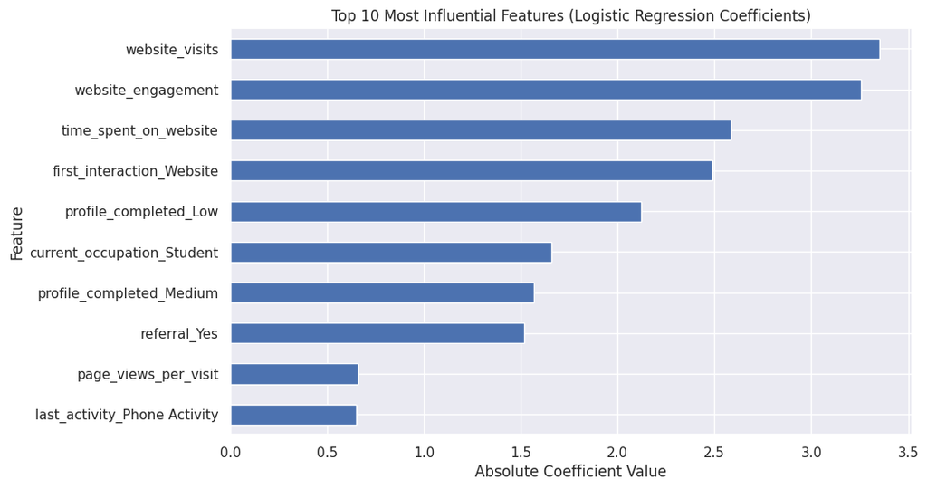

```python
# Get the coefficients from the fitted Logistic Regression model
coefficients = log_reg.coef_[0]

# Create a pandas Series to associate coefficients with feature names
feature_coefficients = pd.Series(coefficients, index=X_train.columns)

# Sort coefficients by their absolute value in descending order to see the most influential features
sorted_feature_coefficients = feature_coefficients.abs().sort_values(ascending=False)

# Display the sorted feature coefficients
print("Feature Importance (Absolute Coefficients) for Logistic Regression:")
display(sorted_feature_coefficients)

# Optionally, display the actual coefficients (with signs) to see the direction of the impact
print("\nFeature Coefficients (with signs) for Logistic Regression:")
display(feature_coefficients.loc[sorted_feature_coefficients.index]) # Display in the same order as sorted absolute values

# You can also visualize the top N most influential features based on absolute coefficients
plt.figure(figsize=(10, 6))
sorted_feature_coefficients.head(10).plot(kind='barh')
plt.title('Top 10 Most Influential Features (Logistic Regression Coefficients)')
plt.xlabel('Absolute Coefficient Value')
plt.ylabel('Feature')
plt.gca().invert_yaxis()
plt.show()
```

#### **Observation on Logistic Regression Model Performance**

Based on the classification report, ROC AUC, confusion matrices, training/testing times, and the analysis of feature coefficients for the Logistic Regression model:

In summary, the Logistic Regression model provides a decent baseline performance, particularly in identifying leads who will not convert. However, there is room for improvement in correctly identifying leads who *will* convert, as indicated by the lower recall and F1-score for the converted class. The feature coefficient analysis highlights key factors influencing the model's predictions, such as website engagement, first interaction method, and profile completion status. The model is efficient and does not appear to be overfitting.